# **Ensemble Techniques Project - Travel Package Purchase Prediction**

**Designation vs. ProdTaken**

```
ProdTaken          0    1   All
Designation
All             3968  920  4888
Executive       1290  552  1842
Manager         1528  204  1732
Senior Manager   618  124   742
AVP              322   20   342
VP               210   20   230
------------------------------------------------------------------------------------------------------------------------
```

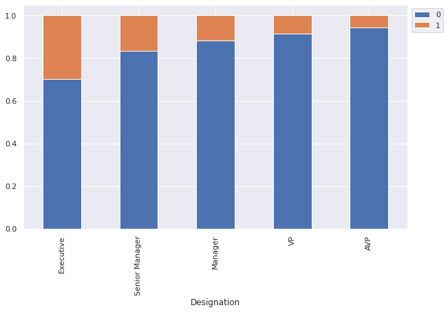

```python
stacked_barplot(tour,'Designation','ProdTaken')
```

Executives buy more tour packages than any other desingation. AVP and VP bought the lowest.

**MaritalStatus vs. ProdTaken**

```
ProdTaken         0    1   All
MaritalStatus
All            3968  920  4888
Married        2014  326  2340
Single          612  304   916
Unmarried       516  166   682
Divorced        826  124   950
------------------------------------------------------------------------------------------------------------------------
```

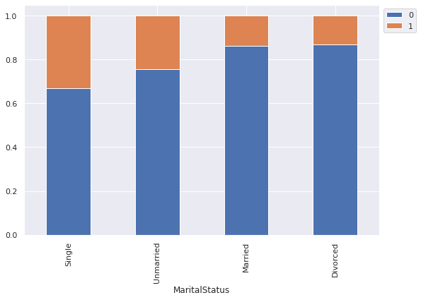

```python
stacked_barplot(tour,'MaritalStatus','ProdTaken')
```

Single and Unmarried people tend to buy more tour packages compare to rest.

**ProductPitched vs. ProdTaken**

```
ProdTaken          0    1   All
ProductPitched
All             3968  920  4888
Basic           1290  552  1842
Deluxe          1528  204  1732
Standard         618  124   742
King             210   20   230
Super Deluxe     322   20   342
------------------------------------------------------------------------------------------------------------------------
```

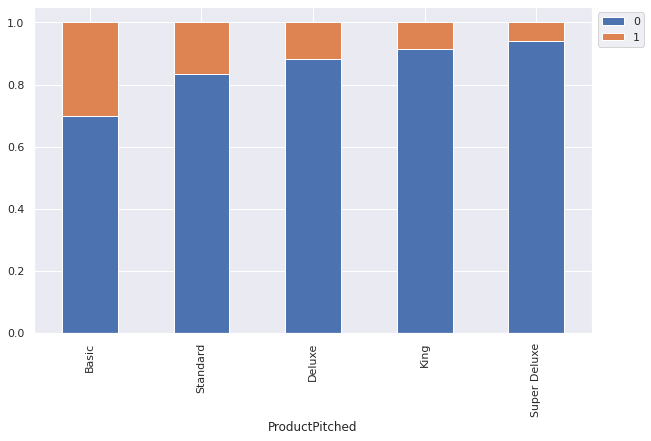

```python
stacked_barplot(tour,'ProductPitched','ProdTaken')
```

**TypeofContact vs. ProdTaken**

```
ProdTaken           0    1   All
TypeofContact
All              3946  917  4863
Self Enquiry     2837  607  3444
Company Invited  1109  310  1419
------------------------------------------------------------------------------------------------------------------------
```

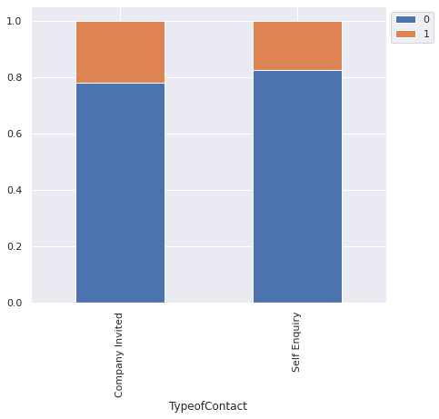

```python
stacked_barplot(tour,'TypeofContact','ProdTaken')
```

The chances of customer buying a tour packages is more when they were invited buy company compare to self inquiry.

**Age vs. ProdTaken**

Age has lot of distinct values. I would like to use the labled_countplot function to do the analysis.

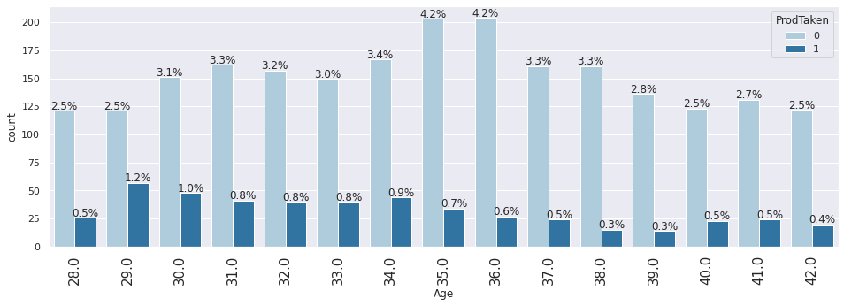

```python
labeled_countplot(tour,'Age',hue='ProdTaken', perc=True, n=15)
```

Age doesn't really affect the rate of Prod Taken. Maximum % of customers buying tour package is around 29-30

**DurationOfPitch vs. Prod Taken**

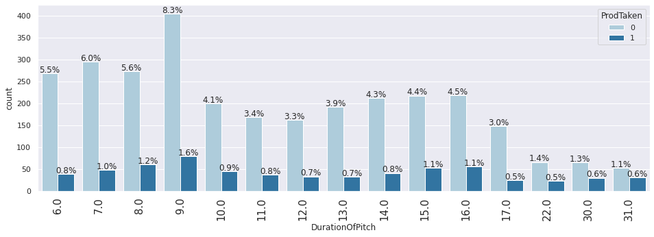

```python
labeled_countplot(tour,'DurationOfPitch',hue='ProdTaken', perc=True, n=15)
```

Duration of pitch doesn't much affect the ProdTaken. When pitch is around 9, more % of customers bought tour package. But its not that high compare to other durations as well.

**NumberOfTrips vs. ProdTaken**

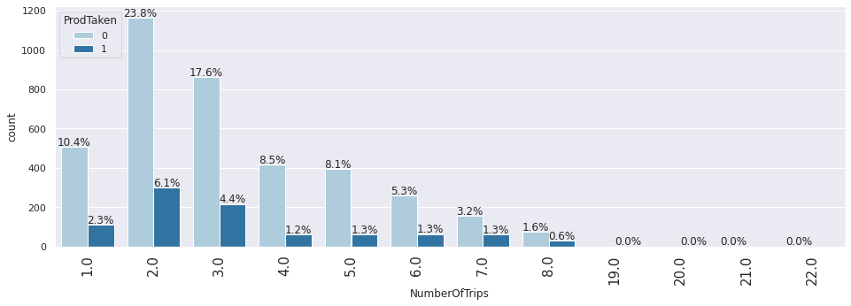

```python
labeled_countplot(tour,'NumberOfTrips',hue='ProdTaken', perc=True, n=15)
```

Customers who take average 2 trips in a year bought the max % of tour packages.

**MontlyIncome vs. ProdTaken**

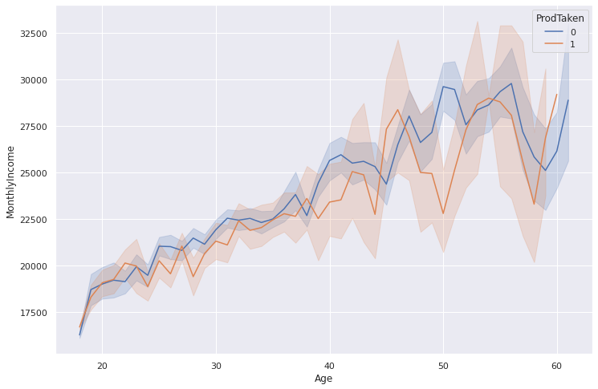

```python
plt.figure(figsize=(12, 8))
sns.lineplot(data=tour,x='Age',y='MonthlyIncome',hue='ProdTaken')
plt.show()
```

**Customer Profiling Based On Packages**

Let's analyze few columns with ProductPitched column to understand customer profile. I will plot all the charts and summarize all packages based on what I see on charts.

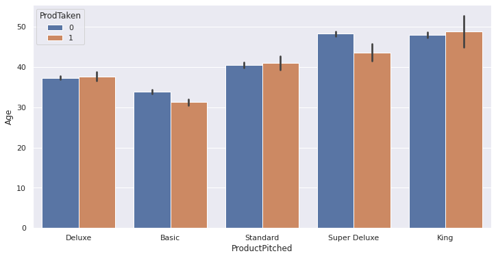

```python
plt.figure(figsize=(12,6))
sns.barplot(y='Age',x='ProductPitched',hue='ProdTaken',data=tour);
```

To understand the age distribution better, let me get some stats on it.

```python
tour.groupby(['ProductPitched']).agg({'Age':{'min','max','mean','median'}})
```

| ProductPitched | Age mean | Age min | Age max | Age median |
| --- | --- | --- | --- | --- |
| Basic | 33.054181 | 18.0 | 60.0 | 32.0 |
| Deluxe | 37.382193 | 21.0 | 61.0 | 36.0 |
| King | 48.065217 | 27.0 | 61.0 | 49.0 |
| Standard | 40.581646 | 19.0 | 61.0 | 38.0 |
| Super Deluxe | 48.026316 | 29.0 | 60.0 | 49.0 |

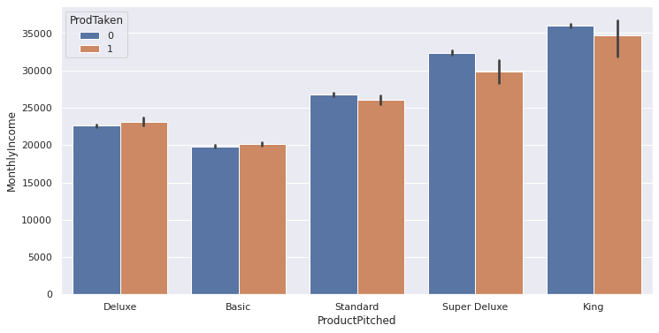

```python
plt.figure(figsize=(12,6))
sns.barplot(y='MonthlyIncome',x='ProductPitched',hue='ProdTaken',data=tour);
```

To understand the MonthlyIncome distribution better, let me get some stats on it.

```python
tour.groupby(['ProductPitched']).agg({'MonthlyIncome':{'min','max','mean','median'}})
```

| ProductPitched | MonthlyIncome mean | MonthlyIncome min | MonthlyIncome max | MonthlyIncome median |
| --- | --- | --- | --- | --- |
| Basic | 19939.922507 | 16009.0 | 98678.0 | 20689.0 |
| Deluxe | 22643.157629 | 1000.0 | 38525.0 | 22922.0 |
| King | 35878.947826 | 17517.0 | 38677.0 | 34999.0 |
| Standard | 26637.749326 | 17372.0 | 38395.0 | 26425.0 |
| Super Deluxe | 32241.046784 | 17705.0 | 37502.0 | 32181.0 |

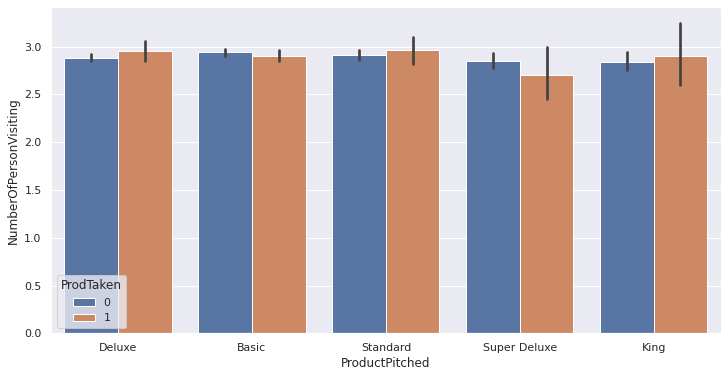

```python
plt.figure(figsize=(12,6))
sns.barplot(y='NumberOfPersonVisiting',x='ProductPitched',hue='ProdTaken',data=tour);
```

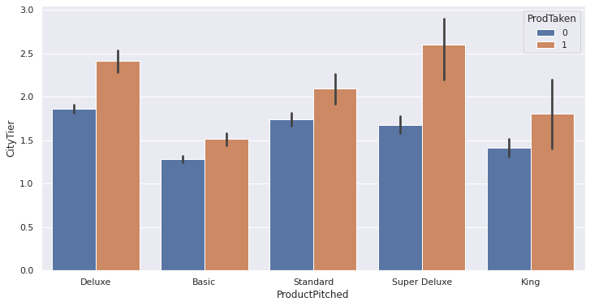

```python
plt.figure(figsize=(12,6))
sns.barplot(y='CityTier',x='ProductPitched',hue='ProdTaken',data=tour);
```

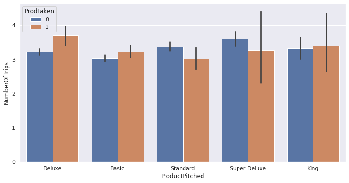

```python
plt.figure(figsize=(12,6))
sns.barplot(y='NumberOfTrips',x='ProductPitched',hue='ProdTaken',data=tour);
```

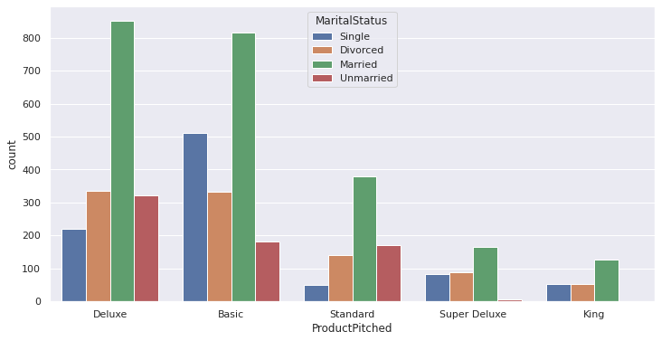

```python
plt.figure(figsize=(12,6))
sns.countplot(data=tour, x="ProductPitched", hue="MaritalStatus");
```

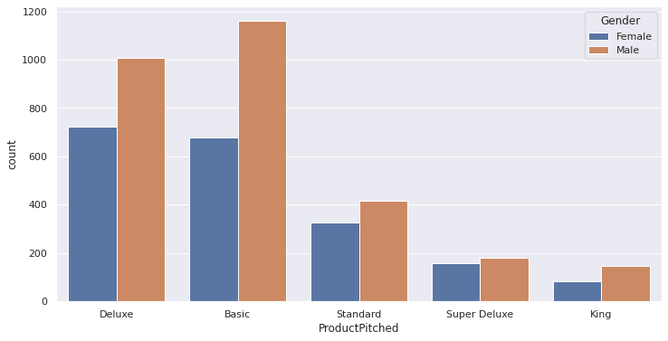

```python
plt.figure(figsize=(12,6))
sns.countplot(data=tour, x="ProductPitched", hue="Gender");
```

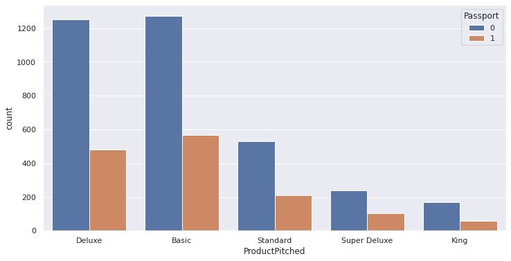

```python
plt.figure(figsize=(12,6))
sns.countplot(data=tour, x="ProductPitched", hue="Passport");
```

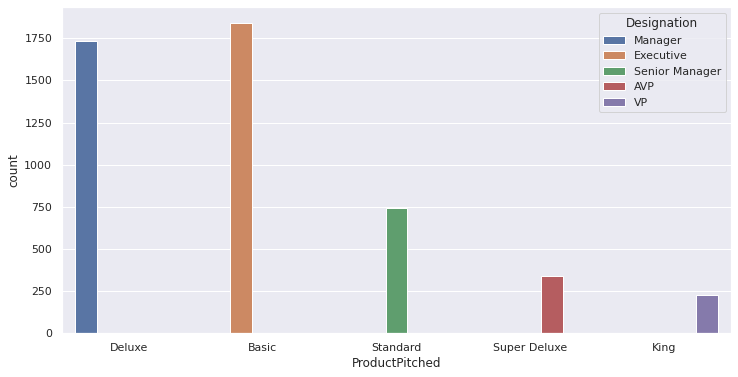

```python
plt.figure(figsize=(12,6))
sns.countplot(data=tour, x="ProductPitched", hue="Designation");
```

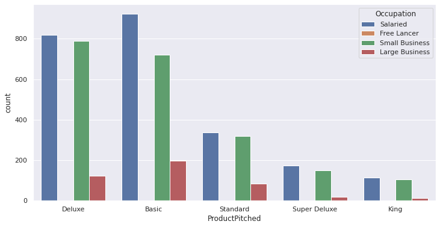

```python
plt.figure(figsize=(12,6))
sns.countplot(data=tour, x="ProductPitched", hue="Occupation");
```

**Customer Profiling by packages -**

**Basic -** Most of the customers here are lower in age(median:32) and monthly income(avg:20K). Majority of them are single or married with Executives working as salaried employee and living in Citytier 1.

**Deluxe -** Most of the customers are bit higher in age(median:36) and monthly income(avg:22K) compare to basic package customers. Mostly they are managers and work as salaried or having small business. Most of them are married and make 3-4 trips a year. Many divorced or unmarried also prefer this package.

**Super Deluxe -** Most of the customers bit older, around age of 49 and having monthly income is also higher around 32K. They are almost equal in male/female ratio. They work as AVP, salaried and married..

### Summary of Observations of EDA

Age - customers are divided across different age groups. Most of them between 18 and 61. There are no outliers and Age doesn't really affect the customer taking Prod Taken.

City Tier - Customers from lower tier cities take more tour packages compare to tier 1 city customers.

Occupation - All Free Lancer customers tend to take tour packages, however the population for such is very low. Customers with large businesses took more tour packages.

Number of Person Visiting - when customer travel with 2,3 or 4 people, take more tour package compare to when they travel alone or with 5 people.

Number of followups - it shows difference in time sales person does the follow ups. More follow ups tend to increase more customers to buy tour packages.

Passport - passport holder customers tend to buy more tour packages, may be tours are more attracted for international travelling.

Designation - More percentage of Executives buy tour packages compare to any other designations.

Pitch Satisfaction Score - higher the satisfaction, higher the chances of customers buying tour packages.

Marital Status - singles and unmarried prefer more tour packages compare to married.

Product Pitched - customers prefer basic pitch, that attracts them to buy more tour packages.

Number of Trips - customers who do 2 trips in a year tend to buy more tour package compare to customers doing less or more than 2.

NumberOfPersonVisiting is positively correlated with NumberOfChildernVisiting. That means, customers who travel with their children(family) tend to buy more tour packages.

None of the columns having bad data that has to be treated. There are some outliers in few columns and it would be checked later to see if its valid or not.

# **4. Data Pre-Processing**

### Missing Values

As observed in 'Exploring Data At High Level' section, there were nulls in few columns. Let's check those.

```python
tour.isna().sum()
```

```
ProdTaken                     0
Age                         226
TypeofContact                25
CityTier                      0
DurationOfPitch             251
Occupation                    0
Gender                        0
NumberOfPersonVisiting        0
NumberOfFollowups            45
ProductPitched                0
PreferredPropertyStar        26
MaritalStatus                 0
NumberOfTrips               140
Passport                      0
PitchSatisfactionScore        0
OwnCar                        0
NumberOfChildrenVisiting     66
Designation                   0
MonthlyIncome               233
dtype: int64
```

**MonthlyIncome**

There are 233 Null MonthlyIncome records. Let's examine top 20.

```python
tour.loc[tour['MonthlyIncome'].isnull()].head(20)
```

|  | ProdTaken | Age | TypeofContact | CityTier | DurationOfPitch | Occupation | Gender | NumberOfPersonVisiting | NumberOfFollowups | ProductPitched | PreferredPropertyStar | MaritalStatus | NumberOfTrips | Passport | PitchSatisfactionScore | OwnCar | NumberOfChildrenVisiting | Designation | MonthlyIncome |
| --- | --- | --- | --- | --- | --- | --- | --- | --- | --- | --- | --- | --- | --- | --- | --- | --- | --- | --- | --- |
| 11 | 0 | NaN | Self Enquiry | 1 | 21.0 | Salaried | Female | 2 | 4.0 | Deluxe | 3.0 | Single | 1.0 | 1 | 3 | 0 | 0.0 | Manager | NaN |
| 19 | 0 | NaN | Self Enquiry | 1 | 8.0 | Salaried | Male | 2 | 3.0 | Basic | 3.0 | Single | 6.0 | 1 | 4 | 0 | 1.0 | Executive | NaN |
| 20 | 0 | NaN | Company Invited | 1 | 17.0 | Salaried | Female | 3 | 2.0 | Deluxe | 3.0 | Married | 1.0 | 0 | 3 | 1 | 2.0 | Manager | NaN |
| 26 | 1 | NaN | Company Invited | 1 | 22.0 | Salaried | Female | 3 | 5.0 | Basic | 5.0 | Single | 2.0 | 1 | 4 | 1 | 2.0 | Executive | NaN |
| 44 | 0 | NaN | Company Invited | 1 | 6.0 | Small Business | Female | 2 | 3.0 | Deluxe | 3.0 | Single | 2.0 | 0 | 3 | 1 | 0.0 | Manager | NaN |
| 54 | 0 | NaN | Self Enquiry | 3 | 29.0 | Small Business | Female | 2 | 4.0 | Deluxe | 3.0 | Divorced | 1.0 | 1 | 2 | 1 | 0.0 | Manager | NaN |
| 57 | 0 | NaN | Self Enquiry | 1 | 29.0 | Small Business | Female | 1 | 3.0 | Basic | 5.0 | Divorced | 4.0 | 1 | 4 | 1 | 0.0 | Executive | NaN |
| 75 | 0 | 31.0 | Self Enquiry | 1 | NaN | Salaried | Female | 3 | 3.0 | Deluxe | 3.0 | Single | 2.0 | 0 | 5 | 0 | 1.0 | Manager | NaN |
| 76 | 0 | 35.0 | Self Enquiry | 3 | NaN | Small Business | Male | 2 | 4.0 | Deluxe | 5.0 | Single | 1.0 | 0 | 2 | 0 | 1.0 | Manager | NaN |
| 84 | 0 | 34.0 | Self Enquiry | 1 | NaN | Small Business | Male | 3 | 3.0 | Deluxe | 4.0 | Divorced | 2.0 | 0 | 5 | 0 | 0.0 | Manager | NaN |
| 88 | 0 | NaN | Self Enquiry | 1 | 8.0 | Salaried | Male | 2 | 4.0 | Deluxe | 3.0 | Divorced | 2.0 | 0 | 4 | 1 | 0.0 | Manager | NaN |
| 97 | 0 | NaN | Company Invited | 3 | 10.0 | Small Business | Male | 2 | 3.0 | Deluxe | 3.0 | Divorced | 2.0 | 0 | 2 | 1 | 0.0 | Manager | NaN |
| 140 | 1 | NaN | Self Enquiry | 1 | 15.0 | Small Business | Female | 2 | 3.0 | Basic | 5.0 | Single | 1.0 | 0 | 4 | 1 | 1.0 | Executive | NaN |
| 155 | 0 | 29.0 | Company Invited | 1 | NaN | Large Business | Male | 2 | 3.0 | Deluxe | 3.0 | Divorced | 2.0 | 0 | 3 | 0 | 1.0 | Manager | NaN |
| 175 | 0 | 56.0 | Self Enquiry | 1 | NaN | Salaried | Female | 3 | 3.0 | Basic | 5.0 | Married | 5.0 | 1 | 4 | 1 | 1.0 | Executive | NaN |
| 180 | 0 | NaN | Self Enquiry | 1 | 18.0 | Small Business | Female | 3 | 3.0 | Basic | 3.0 | Divorced | 1.0 | 1 | 4 | 1 | 2.0 | Executive | NaN |
| 184 | 0 | 53.0 | Self Enquiry | 1 | NaN | Small Business | Female | 2 | 2.0 | Deluxe | 5.0 | Married | 2.0 | 0 | 2 | 1 | 1.0 | Manager | NaN |
| 196 | 0 | 35.0 | Company Invited | 1 | NaN | Small Business | Female | 2 | 3.0 | Deluxe | 4.0 | Single | 6.0 | 0 | 2 | 1 | 0.0 | Manager | NaN |
| 200 | 0 | 27.0 | Company Invited | 1 | NaN | Large Business | Male | 2 | 4.0 | Deluxe | 5.0 | Divorced | 6.0 | 0 | 3 | 0 | 1.0 | Manager | NaN |
| 202 | 0 | NaN | Company Invited | 1 | 16.0 | Small Business | Male | 2 | 3.0 | Basic | 3.0 | Married | 2.0 | 1 | 3 | 1 | 0.0 | Executive | NaN |

There are no visible relation with other columns when MonthlyIncome is Null. Let's check stats on it.

```python
tour.MonthlyIncome.describe()
```

```
count     4655.000000
mean     23619.853491
std       5380.698361
min       1000.000000
25%      20346.000000
50%      22347.000000
75%      25571.000000
max      98678.000000
Name: MonthlyIncome, dtype: float64
```

The mean is ~23K and median is around ~22k. I would like to replace Null MonthlyIncome with mean.

```python
tour.MonthlyIncome.fillna(tour.MonthlyIncome.mean(),inplace=True)
```

**NumberOfChildrenVisiting**

There are 66 Null NumberOfChildrenVisiting reocrds. Let's examine top 20.

```python
tour.loc[tour['NumberOfChildrenVisiting'].isnull()].head(20)
```

|  | ProdTaken | Age | TypeofContact | CityTier | DurationOfPitch | Occupation | Gender | NumberOfPersonVisiting | NumberOfFollowups | ProductPitched | PreferredPropertyStar | MaritalStatus | NumberOfTrips | Passport | PitchSatisfactionScore | OwnCar | NumberOfChildrenVisiting | Designation | MonthlyIncome |
| --- | --- | --- | --- | --- | --- | --- | --- | --- | --- | --- | --- | --- | --- | --- | --- | --- | --- | --- | --- |
| 165 | 0 | 50.0 | Self Enquiry | 1 | 17.0 | Salaried | Female | 2 | 3.0 | King | 4.0 | Single | 4.0 | 0 | 5 | 1 | NaN | VP | 34926.0 |
| 190 | 0 | 52.0 | Self Enquiry | 1 | 6.0 | Salaried | Male | 3 | 4.0 | King | 3.0 | Divorced | 1.0 | 0 | 2 | 1 | NaN | VP | 34999.0 |
| 568 | 1 | 55.0 | Self Enquiry | 1 | 8.0 | Small Business | Male | 3 | 3.0 | King | 5.0 | Divorced | 6.0 | 1 | 2 | 1 | NaN | VP | 34859.0 |
| 746 | 0 | 41.0 | Company Invited | 1 | 13.0 | Salaried | Female | 2 | 5.0 | King | 3.0 | Married | 2.0 | 0 | 4 | 1 | NaN | VP | 34973.0 |
| 749 | 1 | 52.0 | Self Enquiry | 3 | 8.0 | Small Business | Female | 2 | 5.0 | King | 3.0 | Divorced | 2.0 | 0 | 3 | 1 | NaN | VP | 34845.0 |
| 851 | 0 | 56.0 | Self Enquiry | 1 | 10.0 | Large Business | Female | 3 | 3.0 | King | 5.0 | Married | 5.0 | 0 | 4 | 0 | NaN | VP | 34943.0 |
| 898 | 0 | 43.0 | Self Enquiry | 1 | 9.0 | Salaried | Male | 3 | 5.0 | King | 3.0 | Divorced | 4.0 | 0 | 5 | 1 | NaN | VP | 34740.0 |
| 918 | 0 | 51.0 | Company Invited | 3 | 15.0 | Salaried | Male | 2 | 3.0 | King | 4.0 | Married | 5.0 | 1 | 4 | 1 | NaN | VP | 34847.0 |
| 956 | 0 | 56.0 | Self Enquiry | 2 | 14.0 | Salaried | Male | 2 | 3.0 | King | 4.0 | Single | 7.0 | 0 | 4 | 1 | NaN | VP | 34717.0 |
| 1009 | 0 | 58.0 | Self Enquiry | 1 | 6.0 | Small Business | Female | 3 | 3.0 | King | 5.0 | Divorced | 4.0 | 1 | 1 | 1 | NaN | VP | 34701.0 |
| 1154 | 0 | 47.0 | Self Enquiry | 2 | 32.0 | Salaried | Female | 3 | 3.0 | King | 3.0 | Married | 4.0 | 0 | 4 | 1 | NaN | VP | 34658.0 |
| 1242 | 0 | 40.0 | Self Enquiry | 3 | 13.0 | Small Business | Male | 2 | 3.0 | King | 4.0 | Single | 2.0 | 0 | 4 | 1 | NaN | VP | 34833.0 |
| 1331 | 0 | 48.0 | Self Enquiry | 1 | 16.0 | Salaried | Male | 3 | 4.0 | King | 4.0 | Married | 5.0 | 0 | 3 | 1 | NaN | VP | 34665.0 |
| 1401 | 0 | 55.0 | Self Enquiry | 2 | 32.0 | Salaried | Male | 3 | 1.0 | King | 4.0 | Married | 5.0 | 1 | 5 | 1 | NaN | VP | 34636.0 |
| 1635 | 0 | 50.0 | Self Enquiry | 1 | 17.0 | Salaried | Female | 2 | 3.0 | King | 4.0 | Single | 4.0 | 0 | 5 | 0 | NaN | VP | 34926.0 |
| 1660 | 0 | 52.0 | Self Enquiry | 1 | 6.0 | Salaried | Male | 3 | 4.0 | King | 3.0 | Married | 1.0 | 0 | 1 | 1 | NaN | VP | 34999.0 |
| 2038 | 1 | 55.0 | Self Enquiry | 1 | 8.0 | Small Business | Male | 3 | 3.0 | King | 5.0 | Married | 6.0 | 1 | 1 | 1 | NaN | VP | 34859.0 |
| 2216 | 0 | 41.0 | Company Invited | 1 | 13.0 | Salaried | Female | 2 | 5.0 | King | 3.0 | Married | 2.0 | 0 | 4 | 1 | NaN | VP | 34973.0 |
| 2219 | 1 | 52.0 | Self Enquiry | 3 | 8.0 | Small Business | Female | 2 | 5.0 | King | 3.0 | Married | 2.0 | 0 | 3 | 1 | NaN | VP | 34845.0 |
| 2321 | 0 | 56.0 | Self Enquiry | 1 | 10.0 | Large Business | Female | 3 | 3.0 | King | 5.0 | Married | 5.0 | 0 | 4 | 1 | NaN | VP | 34943.0 |

```python
tour.NumberOfChildrenVisiting.fillna(0,inplace=True)
```

**NumberOfTrips**

There are 140 Null NumberOfTrips reocrds. Let's examine top 20.

```python
tour.loc[tour['NumberOfTrips'].isnull()].head(20)
```

|  | ProdTaken | Age | TypeofContact | CityTier | DurationOfPitch | Occupation | Gender | NumberOfPersonVisiting | NumberOfFollowups | ProductPitched | PreferredPropertyStar | MaritalStatus | NumberOfTrips | Passport | PitchSatisfactionScore | OwnCar | NumberOfChildrenVisiting | Designation | MonthlyIncome |
| --- | --- | --- | --- | --- | --- | --- | --- | --- | --- | --- | --- | --- | --- | --- | --- | --- | --- | --- | --- |
| 2469 | 0 | 54.0 | Self Enquiry | 1 | 12.0 | Salaried | Female | 3 | 4.0 | King | 3.0 | Married | NaN | 0 | 5 | 0 | 2.0 | VP | 37772.0 |
| 2473 | 0 | 47.0 | Self Enquiry | 3 | 9.0 | Small Business | Female | 3 | 4.0 | King | 5.0 | Single | NaN | 0 | 2 | 0 | 2.0 | VP | 37625.0 |
| 2506 | 0 | 51.0 | Self Enquiry | 1 | 14.0 | Small Business | Female | 3 | 5.0 | King | 3.0 | Married | NaN | 1 | 4 | 1 | 2.0 | VP | 37418.0 |
| 2549 | 0 | 60.0 | Company Invited | 2 | 9.0 | Salaried | Female | 3 | 5.0 | King | 3.0 | Divorced | NaN | 0 | 2 | 1 | 2.0 | VP | 37522.0 |
| 2550 | 0 | 51.0 | Company Invited | 1 | 7.0 | Salaried | Female | 4 | 4.0 | King | 4.0 | Divorced | NaN | 1 | 2 | 0 | 3.0 | VP | 36850.0 |
| 2556 | 0 | 55.0 | Company Invited | 2 | 33.0 | Salaried | Female | 2 | 3.0 | Super Deluxe | 3.0 | Single | NaN | 1 | 3 | 1 | 1.0 | AVP | 36006.0 |
| 2563 | 0 | 44.0 | Company Invited | 3 | 33.0 | Salaried | Male | 4 | 4.0 | Super Deluxe | 3.0 | Divorced | NaN | 1 | 2 | 0 | 1.0 | AVP | 35637.0 |
| 2567 | 0 | 52.0 | Self Enquiry | 1 | 13.0 | Salaried | Male | 3 | 4.0 | King | 3.0 | Single | NaN | 0 | 5 | 1 | 1.0 | VP | 38215.0 |
| 2591 | 0 | 42.0 | Company Invited | 1 | 17.0 | Salaried | Male | 4 | 5.0 | Super Deluxe | 5.0 | Married | NaN | 0 | 2 | 1 | 1.0 | AVP | 35859.0 |
| 2630 | 0 | 41.0 | Self Enquiry | 1 | 11.0 | Small Business | Female | 3 | 4.0 | King | 3.0 | Divorced | NaN | 0 | 5 | 0 | 2.0 | VP | 37711.0 |
| 2631 | 0 | 56.0 | Self Enquiry | 1 | 21.0 | Small Business | Male | 4 | 3.0 | King | 4.0 | Single | NaN | 0 | 2 | 0 | 3.0 | VP | 37400.0 |
| 2675 | 0 | 43.0 | Self Enquiry | 1 | 11.0 | Large Business | Male | 3 | 4.0 | King | 3.0 | Divorced | NaN | 0 | 2 | 0 | 2.0 | VP | 37910.0 |
| 2677 | 0 | 51.0 | Self Enquiry | 3 | 7.0 | Small Business | Female | 4 | 4.0 | King | 3.0 | Married | NaN | 0 | 2 | 1 | 2.0 | VP | 38195.0 |
| 2681 | 0 | 53.0 | Company Invited | 3 | 9.0 | Salaried | Male | 4 | 5.0 | King | 3.0 | Single | NaN | 1 | 2 | 1 | 3.0 | VP | 37746.0 |
| 2688 | 0 | 46.0 | Self Enquiry | 1 | 7.0 | Salaried | Male | 4 | 3.0 | King | 3.0 | Divorced | NaN | 0 | 4 | 1 | 3.0 | VP | 37880.0 |
| 2701 | 0 | 41.0 | Self Enquiry | 1 | 9.0 | Small Business | Male | 3 | 4.0 | King | 3.0 | Married | NaN | 0 | 5 | 0 | 1.0 | VP | 38114.0 |
| 2714 | 0 | 56.0 | Self Enquiry | 1 | 7.0 | Small Business | Male | 3 | 4.0 | King | 5.0 | Single | NaN | 1 | 2 | 1 | 1.0 | VP | 37723.0 |
| 2723 | 0 | 51.0 | Self Enquiry | 1 | 11.0 | Salaried | Male | 4 | 4.0 | King | 4.0 | Married | NaN | 0 | 5 | 1 | 1.0 | VP | 37822.0 |
| 2724 | 0 | 54.0 | Self Enquiry | 1 | 10.0 | Small Business | Male | 3 | 4.0 | Super Deluxe | 3.0 | Divorced | NaN | 1 | 5 | 0 | 1.0 | AVP | 36262.0 |
| 2734 | 0 | 50.0 | Company Invited | 1 | 17.0 | Salaried | Female | 3 | 4.0 | King | 5.0 | Single | NaN | 1 | 3 | 0 | 1.0 | VP | 37343.0 |

```python
tour.NumberOfTrips.describe()
```

```
count    4748.000000
mean        3.236521
std         1.849019
min         1.000000
25%         2.000000
50%         3.000000
75%         4.000000
max        22.000000
Name: NumberOfTrips, dtype: float64
```

Mean and median both close. I would like to replace all Nulls with median of 3.

```python
tour.NumberOfTrips.fillna(tour['NumberOfTrips'].median(),inplace=True)
```

**PreferredPropertyStar**

There are 26 Null records for PreferredPropertyStar. Let's examine all.

```python
tour.loc[tour['PreferredPropertyStar'].isnull()]
```

|  | ProdTaken | Age | TypeofContact | CityTier | DurationOfPitch | Occupation | Gender | NumberOfPersonVisiting | NumberOfFollowups | ProductPitched | PreferredPropertyStar | MaritalStatus | NumberOfTrips | Passport | PitchSatisfactionScore | OwnCar | NumberOfChildrenVisiting | Designation | MonthlyIncome |
| --- | --- | --- | --- | --- | --- | --- | --- | --- | --- | --- | --- | --- | --- | --- | --- | --- | --- | --- | --- |
| 38 | 0 | 36.0 | Self Enquiry | 1 | 11.0 | Salaried | Female | 2 | 4.0 | Basic | NaN | Divorced | 1.0 | 1 | 2 | 1 | 0.0 | Executive | 95000.0 |
| 2609 | 0 | 51.0 | Self Enquiry | 1 | 18.0 | Salaried | Female | 3 | 4.0 | King | NaN | Single | 5.0 | 0 | 5 | 1 | 1.0 | VP | 38604.0 |
| 2634 | 0 | 53.0 | Self Enquiry | 1 | 7.0 | Salaried | Male | 4 | 5.0 | King | NaN | Divorced | 2.0 | 0 | 2 | 1 | 2.0 | VP | 38677.0 |
| 3012 | 1 | 56.0 | Self Enquiry | 1 | 9.0 | Small Business | Male | 4 | 4.0 | King | NaN | Divorced | 7.0 | 1 | 2 | 1 | 3.0 | VP | 38537.0 |
| 3190 | 0 | 42.0 | Company Invited | 1 | 14.0 | Salaried | Female | 3 | 6.0 | King | NaN | Married | 3.0 | 0 | 4 | 1 | 1.0 | VP | 38651.0 |
| 3193 | 1 | 53.0 | Self Enquiry | 3 | 9.0 | Small Business | Female | 3 | 6.0 | King | NaN | Divorced | 3.0 | 0 | 3 | 1 | 1.0 | VP | 38523.0 |
| 3214 | 0 | 47.0 | Self Enquiry | 1 | 7.0 | Small Business | Male | 3 | 4.0 | King | NaN | Married | 2.0 | 0 | 5 | 1 | 2.0 | VP | 38305.0 |
| 3295 | 0 | 57.0 | Self Enquiry | 1 | 11.0 | Large Business | Female | 4 | 4.0 | King | NaN | Married | 6.0 | 0 | 4 | 0 | 3.0 | VP | 38621.0 |
| 3342 | 0 | 44.0 | Self Enquiry | 1 | 10.0 | Salaried | Male | 4 | 6.0 | King | NaN | Divorced | 5.0 | 0 | 5 | 1 | 3.0 | VP | 38418.0 |
| 3362 | 0 | 52.0 | Company Invited | 3 | 16.0 | Salaried | Male | 3 | 4.0 | King | NaN | Married | 6.0 | 1 | 4 | 1 | 2.0 | VP | 38525.0 |
| 3400 | 0 | 57.0 | Self Enquiry | 2 | 15.0 | Salaried | Male | 3 | 4.0 | King | NaN | Single | 8.0 | 0 | 4 | 1 | 1.0 | VP | 38395.0 |
| 3453 | 0 | 59.0 | Self Enquiry | 1 | 7.0 | Small Business | Female | 4 | 4.0 | King | NaN | Divorced | 5.0 | 1 | 1 | 1 | 3.0 | VP | 38379.0 |
| 3598 | 0 | 48.0 | Self Enquiry | 2 | 33.0 | Salaried | Female | 4 | 4.0 | King | NaN | Married | 5.0 | 0 | 4 | 1 | 2.0 | VP | 38336.0 |
| 3686 | 0 | 41.0 | Self Enquiry | 3 | 14.0 | Small Business | Male | 3 | 4.0 | King | NaN | Single | 3.0 | 0 | 4 | 1 | 2.0 | VP | 38511.0 |
| 3775 | 0 | 49.0 | Self Enquiry | 1 | 17.0 | Salaried | Male | 4 | 5.0 | King | NaN | Married | 6.0 | 0 | 3 | 1 | 2.0 | VP | 38343.0 |
| 3845 | 0 | 56.0 | Self Enquiry | 2 | 33.0 | Salaried | Male | 4 | 2.0 | King | NaN | Married | 6.0 | 1 | 5 | 1 | 3.0 | VP | 38314.0 |
| 4079 | 0 | 51.0 | Self Enquiry | 1 | 18.0 | Salaried | Female | 3 | 4.0 | King | NaN | Single | 5.0 | 0 | 5 | 0 | 2.0 | VP | 38604.0 |
| 4104 | 0 | 53.0 | Self Enquiry | 1 | 7.0 | Salaried | Male | 4 | 5.0 | King | NaN | Married | 2.0 | 0 | 1 | 1 | 3.0 | VP | 38677.0 |
| 4482 | 1 | 56.0 | Self Enquiry | 1 | 9.0 | Small Business | Male | 4 | 4.0 | King | NaN | Married | 7.0 | 1 | 1 | 1 | 1.0 | VP | 38537.0 |
| 4660 | 0 | 42.0 | Company Invited | 1 | 14.0 | Salaried | Female | 3 | 6.0 | King | NaN | Married | 3.0 | 0 | 4 | 1 | 2.0 | VP | 38651.0 |
| 4663 | 1 | 53.0 | Self Enquiry | 3 | 9.0 | Small Business | Female | 3 | 6.0 | King | NaN | Married | 3.0 | 0 | 3 | 1 | 2.0 | VP | 38523.0 |
| 4684 | 0 | 47.0 | Self Enquiry | 1 | 7.0 | Small Business | Male | 3 | 4.0 | King | NaN | Married | 2.0 | 0 | 5 | 1 | 1.0 | VP | 38305.0 |
| 4765 | 0 | 57.0 | Self Enquiry | 1 | 11.0 | Large Business | Female | 4 | 4.0 | King | NaN | Married | 6.0 | 0 | 4 | 1 | 2.0 | VP | 38621.0 |
| 4812 | 0 | 44.0 | Self Enquiry | 1 | 10.0 | Salaried | Male | 4 | 6.0 | King | NaN | Married | 5.0 | 0 | 5 | 1 | 1.0 | VP | 38418.0 |
| 4832 | 1 | 52.0 | Company Invited | 1 | 35.0 | Salaried | Male | 4 | 5.0 | Deluxe | NaN | Single | 5.0 | 0 | 3 | 0 | 1.0 | Manager | 38525.0 |
| 4870 | 1 | 57.0 | Self Enquiry | 3 | 23.0 | Salaried | Female | 4 | 4.0 | Standard | NaN | Single | 4.0 | 1 | 5 | 1 | 3.0 | Senior Manager | 38395.0 |

```python
tour.PreferredPropertyStar.value_counts()
```

```
3.0    2993
5.0     956
4.0     913
Name: PreferredPropertyStar, dtype: int64
```

Maximum records have 3 stars, I would like to replace Nulls with 3

```python
tour.PreferredPropertyStar.fillna(3,inplace=True)
```

**NumberOfFollowups**

There are 45 records with Null NumberOfFollowups, Let's examine all.

```python
tour.loc[tour['NumberOfFollowups'].isna()]
```

|  | ProdTaken | Age | TypeofContact | CityTier | DurationOfPitch | Occupation | Gender | NumberOfPersonVisiting | NumberOfFollowups | ProductPitched | PreferredPropertyStar | MaritalStatus | NumberOfTrips | Passport | PitchSatisfactionScore | OwnCar | NumberOfChildrenVisiting | Designation | MonthlyIncome |
| --- | --- | --- | --- | --- | --- | --- | --- | --- | --- | --- | --- | --- | --- | --- | --- | --- | --- | --- | --- |
| 79 | 0 | 46.0 | Self Enquiry | 2 | 11.0 | Small Business | Male | 3 | NaN | Deluxe | 4.0 | Married | 1.0 | 1 | 5 | 0 | 1.0 | Manager | 20021.0 |
| 94 | 0 | 32.0 | Self Enquiry | 3 | 12.0 | Small Business | Male | 2 | NaN | Deluxe | 3.0 | Single | 2.0 | 0 | 5 | 1 | 0.0 | Manager | 20010.0 |
| 96 | 0 | 24.0 | Self Enquiry | 3 | 9.0 | Salaried | Female | 2 | NaN | Deluxe | 3.0 | Divorced | 1.0 | 0 | 4 | 1 | 0.0 | Manager | 19999.0 |
| 122 | 1 | 56.0 | Self Enquiry | 1 | 20.0 | Salaried | Female | 3 | NaN | Basic | 4.0 | Divorced | 1.0 | 1 | 5 | 1 | 1.0 | Executive | 19963.0 |
| 135 | 0 | 36.0 | Self Enquiry | 1 | 12.0 | Small Business | Male | 2 | NaN | Deluxe | 4.0 | Married | 7.0 | 0 | 4 | 1 | 1.0 | Manager | 19941.0 |
| 174 | 0 | 45.0 | Self Enquiry | 3 | 10.0 | Salaried | Female | 1 | NaN | Deluxe | 5.0 | Married | 5.0 | 1 | 4 | 0 | 0.0 | Manager | 20006.0 |
| 317 | 1 | 52.0 | Self Enquiry | 1 | 14.0 | Small Business | Male | 2 | NaN | Deluxe | 4.0 | Divorced | 3.0 | 0 | 2 | 1 | 1.0 | Manager | 19941.0 |
| 322 | 0 | 32.0 | Self Enquiry | 1 | 8.0 | Small Business | Female | 3 | NaN | Deluxe | 3.0 | Single | 1.0 | 0 | 3 | 1 | 2.0 | Manager | 20055.0 |
| 376 | 0 | 51.0 | Self Enquiry | 3 | 20.0 | Salaried | Female | 2 | NaN | Deluxe | 3.0 | Divorced | 5.0 | 0 | 3 | 0 | 1.0 | Manager | 19936.0 |
| 532 | 0 | 47.0 | Self Enquiry | 3 | 20.0 | Small Business | Male | 2 | NaN | Deluxe | 5.0 | Single | 3.0 | 0 | 2 | 0 | 1.0 | Manager | 19960.0 |
| 629 | 0 | 28.0 | Self Enquiry | 2 | 14.0 | Small Business | Male | 3 | NaN | Basic | 3.0 | Married | 2.0 | 0 | 2 | 0 | 1.0 | Executive | 19936.0 |
| 737 | 0 | 41.0 | Self Enquiry | 1 | 13.0 | Small Business | Female | 2 | NaN | Deluxe | 3.0 | Single | 7.0 | 0 | 3 | 1 | 0.0 | Manager | 20003.0 |
| 748 | 1 | 26.0 | Company Invited | 3 | 35.0 | Small Business | Male | 3 | NaN | Deluxe | 5.0 | Single | 1.0 | 0 | 3 | 0 | 0.0 | Manager | 19969.0 |
| 820 | 0 | 35.0 | Company Invited | 3 | 17.0 | Small Business | Male | 2 | NaN | Deluxe | 3.0 | Married | 2.0 | 0 | 5 | 0 | 0.0 | Manager | 19968.0 |
| 881 | 0 | 32.0 | Company Invited | 1 | 8.0 | Salaried | Female | 2 | NaN | Deluxe | 3.0 | Single | 5.0 | 1 | 5 | 1 | 1.0 | Manager | 19998.0 |
| 885 | 0 | 25.0 | Self Enquiry | 3 | 16.0 | Salaried | Male | 2 | NaN | Deluxe | 3.0 | Single | 1.0 | 0 | 2 | 0 | 1.0 | Manager | 19950.0 |
| 1159 | 0 | 39.0 | Company Invited | 1 | 10.0 | Small Business | Female | 2 | NaN | Deluxe | 3.0 | Single | 1.0 | 0 | 3 | 1 | 0.0 | Manager | 20042.0 |
| 1215 | 0 | 35.0 | Company Invited | 1 | 8.0 | Small Business | Male | 3 | NaN | Basic | 3.0 | Single | 1.0 | 1 | 3 | 1 | 0.0 | Executive | 19930.0 |
| 1234 | 0 | 47.0 | Company Invited | 3 | 8.0 | Small Business | Male | 2 | NaN | Deluxe | 4.0 | Married | 1.0 | 0 | 1 | 0 | 1.0 | Manager | 19978.0 |
| 1244 | 0 | 30.0 | Company Invited | 1 | 8.0 | Large Business | Female | 3 | NaN | Basic | 5.0 | Single | 1.0 | 0 | 3 | 0 | 1.0 | Executive | 19968.0 |
| 1352 | 0 | 44.0 | Self Enquiry | 1 | 6.0 | Salaried | Male | 3 | NaN | Deluxe | 5.0 | Married | 3.0 | 0 | 3 | 1 | 2.0 | Manager | 20033.0 |
| 1389 | 0 | 31.0 | Company Invited | 1 | 6.0 | Salaried | Male | 2 | NaN | Deluxe | 5.0 | Married | 2.0 | 0 | 1 | 1 | 1.0 | Manager | 20003.0 |
| 1549 | 0 | 46.0 | Self Enquiry | 2 | 11.0 | Small Business | Male | 3 | NaN | Deluxe | 4.0 | Married | 1.0 | 1 | 5 | 1 | 2.0 | Manager | 20021.0 |
| 1564 | 0 | 32.0 | Self Enquiry | 3 | 12.0 | Small Business | Male | 2 | NaN | Deluxe | 3.0 | Single | 2.0 | 0 | 5 | 1 | 1.0 | Manager | 20010.0 |
| 1566 | 0 | 24.0 | Self Enquiry | 3 | 9.0 | Salaried | Female | 2 | NaN | Deluxe | 3.0 | Married | 1.0 | 0 | 4 | 0 | 0.0 | Manager | 19999.0 |
| 1592 | 1 | 56.0 | Self Enquiry | 1 | 20.0 | Salaried | Female | 3 | NaN | Basic | 4.0 | Married | 1.0 | 1 | 5 | 1 | 0.0 | Executive | 19963.0 |
| 1605 | 0 | 36.0 | Self Enquiry | 1 | 12.0 | Small Business | Male | 2 | NaN | Deluxe | 4.0 | Married | 7.0 | 0 | 4 | 0 | 1.0 | Manager | 19941.0 |
| 1644 | 0 | 45.0 | Self Enquiry | 3 | 10.0 | Salaried | Female | 1 | NaN | Deluxe | 5.0 | Married | 5.0 | 1 | 4 | 0 | 0.0 | Manager | 20006.0 |
| 1787 | 1 | 52.0 | Self Enquiry | 1 | 14.0 | Small Business | Male | 2 | NaN | Deluxe | 4.0 | Married | 3.0 | 0 | 1 | 1 | 0.0 | Manager | 19941.0 |
| 1846 | 0 | 51.0 | Self Enquiry | 3 | 20.0 | Salaried | Female | 2 | NaN | Deluxe | 3.0 | Married | 5.0 | 0 | 3 | 1 | 0.0 | Manager | 19936.0 |
| 2002 | 0 | 47.0 | Self Enquiry | 3 | 20.0 | Small Business | Male | 2 | NaN | Deluxe | 5.0 | Single | 3.0 | 0 | 1 | 1 | 1.0 | Manager | 19960.0 |
| 2099 | 0 | 28.0 | Self Enquiry | 2 | 14.0 | Small Business | Male | 3 | NaN | Basic | 3.0 | Married | 2.0 | 0 | 1 | 1 | 0.0 | Executive | 19936.0 |
| 2129 | 0 | 28.0 | Self Enquiry | 3 | 11.0 | Small Business | Male | 3 | NaN | Deluxe | 3.0 | Single | 2.0 | 0 | 3 | 0 | 1.0 | Manager | 19908.0 |
| 2207 | 0 | 41.0 | Self Enquiry | 1 | 13.0 | Small Business | Female | 2 | NaN | Deluxe | 3.0 | Single | 7.0 | 0 | 3 | 1 | 1.0 | Manager | 20003.0 |
| 2218 | 1 | 26.0 | Company Invited | 3 | 35.0 | Small Business | Male | 3 | NaN | Deluxe | 5.0 | Single | 1.0 | 0 | 3 | 1 | 1.0 | Manager | 19969.0 |
| 2290 | 0 | 35.0 | Company Invited | 3 | 17.0 | Small Business | Male | 2 | NaN | Deluxe | 3.0 | Married | 2.0 | 0 | 5 | 1 | 1.0 | Manager | 19968.0 |
| 2351 | 0 | 32.0 | Company Invited | 1 | 8.0 | Salaried | Female | 2 | NaN | Deluxe | 3.0 | Single | 5.0 | 1 | 5 | 1 | 0.0 | Manager | 19998.0 |
| 2355 | 0 | 25.0 | Self Enquiry | 3 | 16.0 | Salaried | Male | 2 | NaN | Deluxe | 3.0 | Single | 1.0 | 0 | 1 | 1 | 0.0 | Manager | 19950.0 |
| 2467 | 0 | 22.0 | Self Enquiry | 1 | 22.0 | Salaried | Male | 4 | NaN | Basic | 3.0 | Single | 3.0 | 0 | 3 | 1 | 2.0 | Executive | 19910.0 |
| 2959 | 0 | 36.0 | Company Invited | 1 | 10.0 | Salaried | Male | 3 | NaN | Basic | 3.0 | Divorced | 3.0 | 0 | 2 | 1 | 2.0 | Executive | 19959.0 |
| 3456 | 1 | 32.0 | Company Invited | 3 | 7.0 | Salaried | Female | 3 | NaN | Basic | 3.0 | Single | 3.0 | 0 | 3 | 1 | 2.0 | Executive | 20037.0 |
| 3460 | 1 | 32.0 | Self Enquiry | 1 | 15.0 | Salaried | Female | 3 | NaN | Basic | 4.0 | Single | 3.0 | 0 | 4 | 0 | 2.0 | Executive | 19939.0 |
| 3496 | 0 | 31.0 | Company Invited | 1 | 14.0 | Large Business | Male | 4 | NaN | Basic | 3.0 | Married | 3.0 | 0 | 5 | 0 | 1.0 | Executive | 19952.0 |
| 3937 | 0 | 22.0 | Self Enquiry | 1 | 22.0 | Salaried | Male | 4 | NaN | Basic | 3.0 | Single | 3.0 | 0 | 5 | 1 | 2.0 | Executive | 19910.0 |
| 4429 | 0 | 36.0 | Company Invited | 1 | 10.0 | Salaried | Male | 3 | NaN | Basic | 3.0 | Married | 3.0 | 0 | 1 | 1 | 2.0 | Executive | 19959.0 |

```python
tour.NumberOfFollowups.value_counts()
```

```
4.0    2068
3.0    1466
5.0     768
2.0     229
1.0     176
6.0     136
Name: NumberOfFollowups, dtype: int64
```

```python
tour.NumberOfFollowups.describe()
```

```
count    4843.000000
mean        3.708445
std         1.002509
min         1.000000
25%         3.000000
50%         4.000000
75%         4.000000
max         6.000000
Name: NumberOfFollowups, dtype: float64
```

Rather than assigning any existing values to Null records, I would like to consider Null NumberOfFollowups as 0 as it's possible there was no followup from sales person and that's why this field is empty.

```python
tour['NumberOfFollowups'].fillna(0,inplace=True)
```

**Age**

There are 226 records with Null Age. Let's examine top 20.

```python
tour.loc[tour['Age'].isnull()].head(20)
```

|  | ProdTaken | Age | TypeofContact | CityTier | DurationOfPitch | Occupation | Gender | NumberOfPersonVisiting | NumberOfFollowups | ProductPitched | PreferredPropertyStar | MaritalStatus | NumberOfTrips | Passport | PitchSatisfactionScore | OwnCar | NumberOfChildrenVisiting | Designation | MonthlyIncome |
| --- | --- | --- | --- | --- | --- | --- | --- | --- | --- | --- | --- | --- | --- | --- | --- | --- | --- | --- | --- |
| 4 | 0 | NaN | Self Enquiry | 1 | 8.0 | Small Business | Male | 2 | 3.0 | Basic | 4.0 | Divorced | 1.0 | 0 | 5 | 1 | 0.0 | Executive | 18468.000000 |
| 11 | 0 | NaN | Self Enquiry | 1 | 21.0 | Salaried | Female | 2 | 4.0 | Deluxe | 3.0 | Single | 1.0 | 1 | 3 | 0 | 0.0 | Manager | 23619.853491 |
| 19 | 0 | NaN | Self Enquiry | 1 | 8.0 | Salaried | Male | 2 | 3.0 | Basic | 3.0 | Single | 6.0 | 1 | 4 | 0 | 1.0 | Executive | 23619.853491 |
| 20 | 0 | NaN | Company Invited | 1 | 17.0 | Salaried | Female | 3 | 2.0 | Deluxe | 3.0 | Married | 1.0 | 0 | 3 | 1 | 2.0 | Manager | 23619.853491 |
| 21 | 1 | NaN | Self Enquiry | 3 | 15.0 | Salaried | Male | 2 | 4.0 | Deluxe | 5.0 | Single | 1.0 | 0 | 2 | 0 | 0.0 | Manager | 18407.000000 |
| 26 | 1 | NaN | Company Invited | 1 | 22.0 | Salaried | Female | 3 | 5.0 | Basic | 5.0 | Single | 2.0 | 1 | 4 | 1 | 2.0 | Executive | 23619.853491 |
| 44 | 0 | NaN | Company Invited | 1 | 6.0 | Small Business | Female | 2 | 3.0 | Deluxe | 3.0 | Single | 2.0 | 0 | 3 | 1 | 0.0 | Manager | 23619.853491 |
| 51 | 1 | NaN | Self Enquiry | 1 | 11.0 | Large Business | Male | 2 | 3.0 | Basic | 3.0 | Single | 2.0 | 1 | 2 | 1 | 0.0 | Executive | 18441.000000 |
| 54 | 0 | NaN | Self Enquiry | 3 | 29.0 | Small Business | Female | 2 | 4.0 | Deluxe | 3.0 | Divorced | 1.0 | 1 | 2 | 1 | 0.0 | Manager | 23619.853491 |
| 57 | 0 | NaN | Self Enquiry | 1 | 29.0 | Small Business | Female | 1 | 3.0 | Basic | 5.0 | Divorced | 4.0 | 1 | 4 | 1 | 0.0 | Executive | 23619.853491 |
| 69 | 1 | NaN | Self Enquiry | 1 | 15.0 | Small Business | Male | 3 | 4.0 | Basic | 3.0 | Divorced | 1.0 | 1 | 2 | 0 | 1.0 | Executive | 18388.000000 |
| 88 | 0 | NaN | Self Enquiry | 1 | 8.0 | Salaried | Male | 2 | 4.0 | Deluxe | 3.0 | Divorced | 2.0 | 0 | 4 | 1 | 0.0 | Manager | 23619.853491 |
| 97 | 0 | NaN | Company Invited | 3 | 10.0 | Small Business | Male | 2 | 3.0 | Deluxe | 3.0 | Divorced | 2.0 | 0 | 2 | 1 | 0.0 | Manager | 23619.853491 |
| 140 | 1 | NaN | Self Enquiry | 1 | 15.0 | Small Business | Female | 2 | 3.0 | Basic | 5.0 | Single | 1.0 | 0 | 4 | 1 | 1.0 | Executive | 23619.853491 |
| 141 | 0 | NaN | Self Enquiry | 1 | 35.0 | Small Business | Male | 2 | 3.0 | Basic | 3.0 | Single | 6.0 | 0 | 2 | 1 | 0.0 | Executive | 18452.000000 |
| 180 | 0 | NaN | Self Enquiry | 1 | 18.0 | Small Business | Female | 3 | 3.0 | Basic | 3.0 | Divorced | 1.0 | 1 | 4 | 1 | 2.0 | Executive | 23619.853491 |
| 183 | 0 | NaN | Self Enquiry | 1 | 6.0 | Small Business | Male | 2 | 4.0 | Basic | 3.0 | Divorced | 3.0 | 0 | 3 | 0 | 0.0 | Executive | 18690.000000 |
| 195 | 0 | NaN | Self Enquiry | 1 | 27.0 | Salaried | Male | 3 | 2.0 | Basic | 5.0 | Divorced | 2.0 | 1 | 3 | 0 | 2.0 | Executive | 18564.000000 |
| 202 | 0 | NaN | Company Invited | 1 | 16.0 | Small Business | Male | 2 | 3.0 | Basic | 3.0 | Married | 2.0 | 1 | 3 | 1 | 0.0 | Executive | 23619.853491 |
| 238 | 0 | NaN | Self Enquiry | 3 | 10.0 | Salaried | Female | 2 | 3.0 | Basic | 4.0 | Divorced | 3.0 | 0 | 3 | 1 | 0.0 | Executive | 23619.853491 |

By looking at sample 20 records with Null Age, doesn't look like there is any pattern. The data is randomly missing.

```python
tour.Age.describe()
```

```
count    4662.000000
mean       37.622265
std         9.316387
min        18.000000
25%        31.000000
50%        36.000000
75%        44.000000
max        61.000000
Name: Age, dtype: float64
```

The mean is 37 and median is 36, I would like to replace NaN with median.

```python
tour['Age'].fillna(tour['Age'].median(),inplace=True)
```

**TypeofContact**

There are 25 records with Null TypeofContact. Let's check all.

```python
tour.loc[tour['TypeofContact'].isnull()]
```

|  | ProdTaken | Age | TypeofContact | CityTier | DurationOfPitch | Occupation | Gender | NumberOfPersonVisiting | NumberOfFollowups | ProductPitched | PreferredPropertyStar | MaritalStatus | NumberOfTrips | Passport | PitchSatisfactionScore | OwnCar | NumberOfChildrenVisiting | Designation | MonthlyIncome |
| --- | --- | --- | --- | --- | --- | --- | --- | --- | --- | --- | --- | --- | --- | --- | --- | --- | --- | --- | --- |
| 224 | 0 | 31.0 | NaN | 1 | NaN | Small Business | Male | 2 | 5.0 | Deluxe | 3.0 | Divorced | 1.0 | 0 | 3 | 1 | 0.0 | Manager | 23619.853491 |
| 571 | 0 | 26.0 | NaN | 1 | NaN | Salaried | Female | 3 | 5.0 | Basic | 3.0 | Married | 4.0 | 0 | 4 | 1 | 2.0 | Executive | 23619.853491 |
| 572 | 0 | 29.0 | NaN | 1 | NaN | Small Business | Female | 3 | 3.0 | Deluxe | 3.0 | Divorced | 5.0 | 0 | 2 | 1 | 0.0 | Manager | 23619.853491 |
| 576 | 0 | 27.0 | NaN | 3 | NaN | Small Business | Male | 2 | 3.0 | Deluxe | 3.0 | Divorced | 1.0 | 0 | 3 | 0 | 1.0 | Manager | 23619.853491 |
| 579 | 0 | 34.0 | NaN | 1 | NaN | Small Business | Female | 2 | 4.0 | Basic | 5.0 | Single | 2.0 | 0 | 2 | 1 | 1.0 | Executive | 23619.853491 |
| 598 | 1 | 28.0 | NaN | 1 | NaN | Small Business | Male | 2 | 3.0 | Basic | 3.0 | Single | 7.0 | 0 | 3 | 0 | 0.0 | Executive | 23619.853491 |
| 622 | 0 | 32.0 | NaN | 3 | NaN | Salaried | Male | 3 | 3.0 | Deluxe | 3.0 | Married | 3.0 | 0 | 2 | 0 | 0.0 | Manager | 23619.853491 |
| 724 | 0 | 24.0 | NaN | 1 | NaN | Small Business | Female | 2 | 4.0 | Deluxe | 3.0 | Married | 2.0 | 0 | 3 | 1 | 1.0 | Manager | 23619.853491 |
| 843 | 0 | 26.0 | NaN | 1 | NaN | Small Business | Male | 2 | 1.0 | Basic | 3.0 | Divorced | 2.0 | 0 | 5 | 1 | 1.0 | Executive | 23619.853491 |
| 1021 | 1 | 25.0 | NaN | 3 | NaN | Salaried | Male | 3 | 4.0 | Basic | 5.0 | Divorced | 4.0 | 0 | 1 | 1 | 0.0 | Executive | 23619.853491 |
| 1047 | 0 | 33.0 | NaN | 3 | NaN | Small Business | Male | 2 | 3.0 | Deluxe | 5.0 | Divorced | 1.0 | 0 | 3 | 0 | 0.0 | Manager | 23619.853491 |
| 1143 | 0 | 45.0 | NaN | 3 | NaN | Small Business | Male | 2 | 4.0 | Deluxe | 5.0 | Married | 2.0 | 0 | 3 | 0 | 0.0 | Manager | 23619.853491 |
| 1182 | 0 | 36.0 | NaN | 1 | NaN | Small Business | Female | 2 | 4.0 | Deluxe | 3.0 | Married | 1.0 | 0 | 5 | 1 | 1.0 | Manager | 23619.853491 |
| 1217 | 0 | 24.0 | NaN | 1 | NaN | Small Business | Male | 3 | 1.0 | Basic | 3.0 | Married | 2.0 | 0 | 1 | 0 | 0.0 | Executive | 23619.853491 |
| 1356 | 0 | 41.0 | NaN | 3 | NaN | Small Business | Female | 2 | 3.0 | Deluxe | 4.0 | Married | 6.0 | 0 | 3 | 1 | 1.0 | Manager | 23619.853491 |
| 1469 | 0 | 34.0 | NaN | 1 | NaN | Small Business | Male | 2 | 1.0 | Deluxe | 3.0 | Married | 3.0 | 0 | 3 | 0 | 1.0 | Manager | 23619.853491 |
| 1694 | 0 | 31.0 | NaN | 1 | NaN | Small Business | Male | 2 | 5.0 | Deluxe | 3.0 | Married | 1.0 | 0 | 3 | 0 | 0.0 | Manager | 23619.853491 |
| 2041 | 0 | 26.0 | NaN | 1 | NaN | Salaried | Female | 3 | 5.0 | Basic | 3.0 | Married | 4.0 | 0 | 4 | 1 | 0.0 | Executive | 23619.853491 |
| 2042 | 0 | 29.0 | NaN | 1 | NaN | Small Business | Female | 3 | 3.0 | Deluxe | 3.0 | Married | 5.0 | 0 | 1 | 0 | 1.0 | Manager | 23619.853491 |
| 2046 | 0 | 27.0 | NaN | 3 | NaN | Small Business | Male | 2 | 3.0 | Deluxe | 3.0 | Married | 1.0 | 0 | 3 | 1 | 1.0 | Manager | 23619.853491 |
| 2049 | 0 | 34.0 | NaN | 1 | NaN | Small Business | Female | 2 | 4.0 | Basic | 5.0 | Single | 2.0 | 0 | 1 | 1 | 0.0 | Executive | 23619.853491 |
| 2068 | 1 | 28.0 | NaN | 1 | NaN | Small Business | Male | 2 | 3.0 | Basic | 3.0 | Single | 7.0 | 0 | 3 | 1 | 1.0 | Executive | 23619.853491 |
| 2092 | 0 | 32.0 | NaN | 3 | NaN | Salaried | Male | 3 | 3.0 | Deluxe | 3.0 | Married | 3.0 | 0 | 1 | 0 | 2.0 | Manager | 23619.853491 |
| 2194 | 0 | 24.0 | NaN | 1 | NaN | Small Business | Female | 2 | 4.0 | Deluxe | 3.0 | Married | 2.0 | 0 | 3 | 0 | 0.0 | Manager | 23619.853491 |
| 2313 | 0 | 26.0 | NaN | 1 | NaN | Small Business | Male | 2 | 1.0 | Basic | 3.0 | Married | 2.0 | 0 | 5 | 1 | 1.0 | Executive | 23619.853491 |

Whenever TypeofContact is Null, DurationOfPitch and MonltyIncome are Null as well. However, DurationOfPitch and MonltyIncome are Null for lot many records.

```python
# checking different values of TypeofContact
tour['TypeofContact'].value_counts()
```

```
Self Enquiry       3444
Company Invited    1419
Name: TypeofContact, dtype: int64
```

By looking at existing values and the pattern in correlation with other columns, it is hard to predict what value should be assigned to Null records, so I would like to put those under new value called 'Unknown'.

```python
tour['TypeofContact'].fillna('Unknown',inplace=True)
```

**DurationOfPitch**

There are 251 records with Null DurationOfPitch. Let's examine top 20.

```python
tour.loc[tour['DurationOfPitch'].isnull()].head(20)
```

|  | ProdTaken | Age | TypeofContact | CityTier | DurationOfPitch | Occupation | Gender | NumberOfPersonVisiting | NumberOfFollowups | ProductPitched | PreferredPropertyStar | MaritalStatus | NumberOfTrips | Passport | PitchSatisfactionScore | OwnCar | NumberOfChildrenVisiting | Designation | MonthlyIncome |
| --- | --- | --- | --- | --- | --- | --- | --- | --- | --- | --- | --- | --- | --- | --- | --- | --- | --- | --- | --- |
| 46 | 0 | 34.0 | Company Invited | 3 | NaN | Small Business | Male | 3 | 3.0 | Deluxe | 3.0 | Single | 1.0 | 0 | 5 | 1 | 1.0 | Manager | 19568.000000 |
| 75 | 0 | 31.0 | Self Enquiry | 1 | NaN | Salaried | Female | 3 | 3.0 | Deluxe | 3.0 | Single | 2.0 | 0 | 5 | 0 | 1.0 | Manager | 23619.853491 |
| 76 | 0 | 35.0 | Self Enquiry | 3 | NaN | Small Business | Male | 2 | 4.0 | Deluxe | 5.0 | Single | 1.0 | 0 | 2 | 0 | 1.0 | Manager | 23619.853491 |
| 84 | 0 | 34.0 | Self Enquiry | 1 | NaN | Small Business | Male | 3 | 3.0 | Deluxe | 4.0 | Divorced | 2.0 | 0 | 5 | 0 | 0.0 | Manager | 23619.853491 |
| 103 | 0 | 34.0 | Self Enquiry | 1 | NaN | Salaried | Female | 2 | 3.0 | Deluxe | 3.0 | Single | 2.0 | 0 | 3 | 1 | 0.0 | Manager | 19809.000000 |
| 114 | 0 | 34.0 | Self Enquiry | 1 | NaN | Salaried | Female | 2 | 4.0 | Deluxe | 4.0 | Married | 7.0 | 0 | 3 | 0 | 1.0 | Manager | 19505.000000 |
| 130 | 0 | 43.0 | Company Invited | 1 | NaN | Small Business | Female | 3 | 2.0 | Basic | 3.0 | Single | 5.0 | 0 | 3 | 0 | 2.0 | Executive | 19739.000000 |
| 132 | 1 | 31.0 | Self Enquiry | 3 | NaN | Salaried | Female | 3 | 5.0 | Deluxe | 3.0 | Divorced | 4.0 | 1 | 3 | 1 | 0.0 | Manager | 19559.000000 |
| 144 | 0 | 32.0 | Company Invited | 3 | NaN | Small Business | Male | 2 | 5.0 | Deluxe | 3.0 | Married | 1.0 | 0 | 2 | 0 | 1.0 | Manager | 19668.000000 |
| 155 | 0 | 29.0 | Company Invited | 1 | NaN | Large Business | Male | 2 | 3.0 | Deluxe | 3.0 | Divorced | 2.0 | 0 | 3 | 0 | 1.0 | Manager | 23619.853491 |
| 175 | 0 | 56.0 | Self Enquiry | 1 | NaN | Salaried | Female | 3 | 3.0 | Basic | 5.0 | Married | 5.0 | 1 | 4 | 1 | 1.0 | Executive | 23619.853491 |
| 184 | 0 | 53.0 | Self Enquiry | 1 | NaN | Small Business | Female | 2 | 2.0 | Deluxe | 5.0 | Married | 2.0 | 0 | 2 | 1 | 1.0 | Manager | 23619.853491 |
| 196 | 0 | 35.0 | Company Invited | 1 | NaN | Small Business | Female | 2 | 3.0 | Deluxe | 4.0 | Single | 6.0 | 0 | 2 | 1 | 0.0 | Manager | 23619.853491 |
| 200 | 0 | 27.0 | Company Invited | 1 | NaN | Large Business | Male | 2 | 4.0 | Deluxe | 5.0 | Divorced | 6.0 | 0 | 3 | 0 | 1.0 | Manager | 23619.853491 |
| 208 | 0 | 40.0 | Company Invited | 1 | NaN | Salaried | Male | 3 | 4.0 | Deluxe | 3.0 | Divorced | 1.0 | 0 | 5 | 1 | 0.0 | Manager | 19876.000000 |
| 224 | 0 | 31.0 | Unknown | 1 | NaN | Small Business | Male | 2 | 5.0 | Deluxe | 3.0 | Divorced | 1.0 | 0 | 3 | 1 | 0.0 | Manager | 23619.853491 |
| 241 | 0 | 32.0 | Company Invited | 3 | NaN | Small Business | Male | 3 | 3.0 | Deluxe | 3.0 | Divorced | 1.0 | 0 | 4 | 1 | 2.0 | Manager | 23619.853491 |
| 255 | 0 | 25.0 | Self Enquiry | 1 | NaN | Salaried | Female | 3 | 3.0 | Deluxe | 3.0 | Divorced | 1.0 | 0 | 3 | 1 | 1.0 | Manager | 19898.000000 |
| 282 | 0 | 29.0 | Company Invited | 3 | NaN | Salaried | Male | 2 | 3.0 | Deluxe | 3.0 | Single | 2.0 | 0 | 2 | 0 | 0.0 | Manager | 19554.000000 |
| 284 | 0 | 26.0 | Company Invited | 1 | NaN | Small Business | Male | 2 | 3.0 | Deluxe | 5.0 | Divorced | 2.0 | 1 | 3 | 1 | 1.0 | Manager | 19741.000000 |

It seems like its null at random records. Doesn't really seem to have a pattern. Let's check stats on this column.

```python
tour['DurationOfPitch'].describe()
```

```
count    4637.000000
mean       15.490835
std         8.519643
min         5.000000
25%         9.000000
50%        13.000000
75%        20.000000
max       127.000000
Name: DurationOfPitch, dtype: float64
```

I would like to replace Nulls with median value of 13

```python
tour['DurationOfPitch'].fillna(13,inplace=True)
```

Let's check for missing values one more time to make sure

```python
tour.isna().sum()
```

```
ProdTaken                   0
Age                         0
TypeofContact               0
CityTier                    0
DurationOfPitch             0
Occupation                  0
Gender                      0
NumberOfPersonVisiting      0
NumberOfFollowups           0
ProductPitched              0
PreferredPropertyStar       0
MaritalStatus               0
NumberOfTrips               0
Passport                    0
PitchSatisfactionScore      0
OwnCar                      0
NumberOfChildrenVisiting    0
Designation                 0
MonthlyIncome               0
dtype: int64
```

Everything looks good.

### Outlier Detection and Treatment

Let's check outliers found in EDA section - MonthlyIncome, DurationOfPitch, NumberOfTrips

**MonthlyIncome**

During EDA, it was observed there were many records right after right whisker uptil around 39K mark. However, there were few way after that as well. I would like to check all those customers with MonthlyIncome of more than 39K per month.

```python
tour.loc[tour['MonthlyIncome']>39000]
```

|  | ProdTaken | Age | TypeofContact | CityTier | DurationOfPitch | Occupation | Gender | NumberOfPersonVisiting | NumberOfFollowups | ProductPitched | PreferredPropertyStar | MaritalStatus | NumberOfTrips | Passport | PitchSatisfactionScore | OwnCar | NumberOfChildrenVisiting | Designation | MonthlyIncome |
| --- | --- | --- | --- | --- | --- | --- | --- | --- | --- | --- | --- | --- | --- | --- | --- | --- | --- | --- | --- |
| 38 | 0 | 36.0 | Self Enquiry | 1 | 11.0 | Salaried | Female | 2 | 4.0 | Basic | 3.0 | Divorced | 1.0 | 1 | 2 | 1 | 0.0 | Executive | 95000.0 |
| 2482 | 0 | 37.0 | Self Enquiry | 1 | 12.0 | Salaried | Female | 3 | 5.0 | Basic | 5.0 | Divorced | 2.0 | 1 | 2 | 1 | 1.0 | Executive | 98678.0 |

Above 2 records way out of range compare to other customers. I would like to treak them to make it around right whisker.

Also, during EDA observed that there were few records way below left whisker. I would like to check those records by checking all records below 15k.

```python
tour.loc[tour['MonthlyIncome']<15000]
```

|  | ProdTaken | Age | TypeofContact | CityTier | DurationOfPitch | Occupation | Gender | NumberOfPersonVisiting | NumberOfFollowups | ProductPitched | PreferredPropertyStar | MaritalStatus | NumberOfTrips | Passport | PitchSatisfactionScore | OwnCar | NumberOfChildrenVisiting | Designation | MonthlyIncome |
| --- | --- | --- | --- | --- | --- | --- | --- | --- | --- | --- | --- | --- | --- | --- | --- | --- | --- | --- | --- |
| 142 | 0 | 38.0 | Self Enquiry | 1 | 9.0 | Large Business | Female | 2 | 3.0 | Deluxe | 3.0 | Single | 4.0 | 1 | 5 | 0 | 0.0 | Manager | 1000.0 |
| 2586 | 0 | 39.0 | Self Enquiry | 1 | 10.0 | Large Business | Female | 3 | 4.0 | Deluxe | 3.0 | Single | 5.0 | 1 | 5 | 0 | 1.0 | Manager | 4678.0 |

Creating function to treat outliers. As we know there are many customers after right whisker that look ok. So I am going to multiply IQR (inter quantile range) with 2.75 to create upper whisker. For lower whisker, will keep IQR at standard of 1.5.

```python
def treat_outliers(df, col, low_iqr=1.5, upp_iqr=1.5):
    """
    treats outliers in a variable
    col: str, name of the numerical variable
    df: dataframe
    col: name of the column
    """
    Q1 = df[col].quantile(0.25)  # 25th quantile
    Q3 = df[col].quantile(0.75)  # 75th quantile
    IQR = Q3 - Q1                # Inter Quantile Range (75th perentile - 25th percentile)
    lower_whisker = Q1 - low_iqr * IQR
    upper_whisker = Q3 + upp_iqr * IQR

    # all the values smaller than lower_whisker will be assigned the value of lower_whisker
    # all the values greater than upper_whisker will be assigned the value of upper_whisker
    # the assignment will be done by using the clip function of NumPy
    df[col] = np.clip(df[col], lower_whisker, upper_whisker)

    return df
```

```python
# to find the 25th percentile and 75th percentile for the numerical columns.
Q1 = tour['NumberOfTrips'].quantile(0.25)
Q3 = tour['NumberOfTrips'].quantile(0.75)

IQR = Q3 - Q1                   #Inter Quantile Range (75th percentile - 25th percentile)

lower_whisker = Q1 - 1*IQR    #Finding lower and upper bounds for all values. All values outside these bounds are outliers
upper_whisker = Q3 + 1.5*IQR
```

```python
lower_whisker
```

```
0.0
```

```python
upper_whisker
```

```
7.0
```

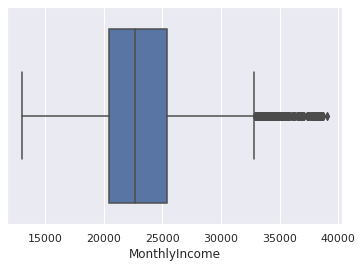

```python
tour = treat_outliers(tour,'MonthlyIncome',1.5,2.75)
# visualizing the column after outlier treatment
sns.boxplot(data=tour,x='MonthlyIncome')
plt.show()
```

Looks good, as expected.

**DurationOfPitch**

As observed during EDA, checking records with DurationOfPitch after 38 min

```python
tour.loc[tour['DurationOfPitch']>38]
```

|  | ProdTaken | Age | TypeofContact | CityTier | DurationOfPitch | Occupation | Gender | NumberOfPersonVisiting | NumberOfFollowups | ProductPitched | PreferredPropertyStar | MaritalStatus | NumberOfTrips | Passport | PitchSatisfactionScore | OwnCar | NumberOfChildrenVisiting | Designation | MonthlyIncome |
| --- | --- | --- | --- | --- | --- | --- | --- | --- | --- | --- | --- | --- | --- | --- | --- | --- | --- | --- | --- |
| 1434 | 0 | 36.0 | Company Invited | 3 | 126.0 | Salaried | Male | 2 | 3.0 | Basic | 3.0 | Married | 3.0 | 0 | 1 | 1 | 1.0 | Executive | 18482.0 |
| 3878 | 0 | 53.0 | Company Invited | 3 | 127.0 | Salaried | Male | 3 | 4.0 | Basic | 3.0 | Married | 4.0 | 0 | 1 | 1 | 2.0 | Executive | 22160.0 |

DurationOfPitch of above 2 records look very high. I would like treat those with IQR of 1.5.

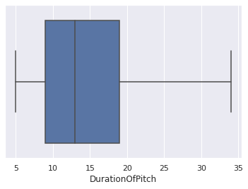

```python
tour = treat_outliers(tour,'DurationOfPitch')
# visualizing the column after outlier treatment
sns.boxplot(data=tour,x='DurationOfPitch')
plt.show()
```

Looks good.

**NumberOfTrips**

As observed during EDA, checking NumberOfTrips more than 8

```python
tour.loc[tour['NumberOfTrips']>8]
```

|  | ProdTaken | Age | TypeofContact | CityTier | DurationOfPitch | Occupation | Gender | NumberOfPersonVisiting | NumberOfFollowups | ProductPitched | PreferredPropertyStar | MaritalStatus | NumberOfTrips | Passport | PitchSatisfactionScore | OwnCar | NumberOfChildrenVisiting | Designation | MonthlyIncome |
| --- | --- | --- | --- | --- | --- | --- | --- | --- | --- | --- | --- | --- | --- | --- | --- | --- | --- | --- | --- |
| 385 | 1 | 30.0 | Company Invited | 1 | 10.0 | Large Business | Male | 2 | 3.0 | Basic | 3.0 | Single | 19.0 | 1 | 4 | 1 | 1.0 | Executive | 17285.0 |
| 816 | 0 | 39.0 | Company Invited | 1 | 15.0 | Salaried | Male | 3 | 3.0 | Deluxe | 4.0 | Unmarried | 21.0 | 0 | 2 | 1 | 0.0 | Manager | 21782.0 |
| 2829 | 1 | 31.0 | Company Invited | 1 | 11.0 | Large Business | Male | 3 | 4.0 | Basic | 3.0 | Single | 20.0 | 1 | 4 | 1 | 2.0 | Executive | 20963.0 |
| 3260 | 0 | 40.0 | Company Invited | 1 | 16.0 | Salaried | Male | 4 | 4.0 | Deluxe | 4.0 | Unmarried | 22.0 | 0 | 2 | 1 | 1.0 | Manager | 25460.0 |

All of above records look higher than usual. I would like to treat those by multiplying with 1.5 IQR.

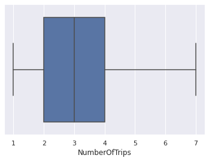

```python
tour = treat_outliers(tour,'NumberOfTrips')
# visualizing the column after outlier treatment
sns.boxplot(data=tour,x='NumberOfTrips')
plt.show()
```

Looks good.

### Feature Engineering

Let's convert all 'object' columns to 'category'

```python
for feature in tour.columns: # Loop through all columns in the dataframe
    if tour[feature].dtype == 'object': # Only apply for columns with categorical strings
        tour[feature] = pd.Categorical(tour[feature])# Replace strings with an integer
```

Check types to make sure -

```python
tour.dtypes
```

```
ProdTaken                      int64
Age                          float64
TypeofContact               category
CityTier                       int64
DurationOfPitch              float64
Occupation                  category
Gender                      category
NumberOfPersonVisiting         int64
NumberOfFollowups            float64
ProductPitched              category
PreferredPropertyStar        float64
MaritalStatus               category
NumberOfTrips                float64
Passport                       int64
PitchSatisfactionScore         int64
OwnCar                         int64
NumberOfChildrenVisiting     float64
Designation                 category
MonthlyIncome                float64
dtype: object
```

Looks good. Let's make a list of all category columns

```python
cat_cols=[]
for feature in tour.columns: # Loop through all columns in the dataframe
    if tour[feature].dtype == 'category': # Only apply for columns with categorical strings
        cat_cols.append(feature)
cat_cols
```

```
['TypeofContact',
 'Occupation',
 'Gender',
 'ProductPitched',
 'MaritalStatus',
 'Designation']
```

Let's examine all the category columns.

```python
for i in cat_cols:
  print (i)
  print(tour[i].value_counts())
```

```
TypeofContact
Self Enquiry       3444
Company Invited    1419
Unknown              25
Name: TypeofContact, dtype: int64
Occupation
Salaried          2368
Small Business    2084
Large Business     434
Free Lancer          2
Name: Occupation, dtype: int64
Gender
Male      2916
Female    1972
Name: Gender, dtype: int64
ProductPitched
Basic           1842
Deluxe          1732
Standard         742
Super Deluxe     342
King             230
Name: ProductPitched, dtype: int64
MaritalStatus
Married      2340
Divorced      950
Single        916
Unmarried     682
Name: MaritalStatus, dtype: int64
Designation
Executive         1842
Manager           1732
Senior Manager     742
AVP                342
VP                 230
Name: Designation, dtype: int64
```

All the distinct values look ok. We can do one-hot coding on all of the above columns.

```python
tour=pd.get_dummies(tour, columns=cat_cols)
tour.head(5)
```

|  | ProdTaken | Age | CityTier | DurationOfPitch | NumberOfPersonVisiting | NumberOfFollowups | PreferredPropertyStar | NumberOfTrips | Passport | PitchSatisfactionScore | OwnCar | NumberOfChildrenVisiting | MonthlyIncome | TypeofContact_Company Invited | TypeofContact_Self Enquiry | TypeofContact_Unknown | Occupation_Free Lancer | Occupation_Large Business | Occupation_Salaried | Occupation_Small Business | Gender_Female | Gender_Male | ProductPitched_Basic | ProductPitched_Deluxe | ProductPitched_King | ProductPitched_Standard | ProductPitched_Super Deluxe | MaritalStatus_Divorced | MaritalStatus_Married | … |
| --- | --- | --- | --- | --- | --- | --- | --- | --- | --- | --- | --- | --- | --- | --- | --- | --- | --- | --- | --- | --- | --- | --- | --- | --- | --- | --- | --- | --- | --- | --- |
| 0 | 1 | 41.0 | 3 | 6.0 | 3 | 3.0 | 3.0 | 1.0 | 1 | 2 | 1 | 0.0 | 20993.0 | 0 | 1 | 0 | 0 | 0 | 1 | 0 | 1 | 0 | 0 | 1 | 0 | 0 | 0 | 0 | 0 | … |
| 1 | 0 | 49.0 | 1 | 14.0 | 3 | 4.0 | 4.0 | 2.0 | 0 | 3 | 1 | 2.0 | 20130.0 | 1 | 0 | 0 | 0 | 0 | 1 | 0 | 0 | 1 | 0 | 1 | 0 | 0 | 0 | 1 | 0 | … |
| 2 | 1 | 37.0 | 1 | 8.0 | 3 | 4.0 | 3.0 | 7.0 | 1 | 3 | 0 | 0.0 | 17090.0 | 0 | 1 | 0 | 1 | 0 | 0 | 0 | 0 | 1 | 1 | 0 | 0 | 0 | 0 | 0 | 0 | … |
| 3 | 0 | 33.0 | 1 | 9.0 | 2 | 3.0 | 3.0 | 2.0 | 1 | 5 | 1 | 1.0 | 17909.0 | 1 | 0 | 0 | 0 | 0 | 1 | 0 | 1 | 0 | 1 | 0 | 0 | 0 | 0 | 1 | 0 | … |
| 4 | 0 | 36.0 | 1 | 8.0 | 2 | 3.0 | 4.0 | 1.0 | 0 | 5 | 1 | 0.0 | 18468.0 | 0 | 1 | 0 | 0 | 0 | 0 | 1 | 0 | 1 | 1 | 0 | 0 | 0 | 0 | 1 | 0 | … |

Check datatypes one more time

```python
tour.info()
```

```
<class 'pandas.core.frame.DataFrame'>
RangeIndex: 4888 entries, 0 to 4887
Data columns (total 36 columns):
 #   Column                         Non-Null Count  Dtype
---  ------                         --------------  -----
 0   ProdTaken                      4888 non-null   int64
 1   Age                            4888 non-null   float64
 2   CityTier                       4888 non-null   int64
 3   DurationOfPitch                4888 non-null   float64
 4   NumberOfPersonVisiting         4888 non-null   int64
 5   NumberOfFollowups              4888 non-null   float64
 6   PreferredPropertyStar          4888 non-null   float64
 7   NumberOfTrips                  4888 non-null   float64
 8   Passport                       4888 non-null   int64
 9   PitchSatisfactionScore         4888 non-null   int64
```

[output cut: 28 more lines]

Everything looks good.

# **5. Model building - Comman Pre Tasks**

In this section, we will perform tasks that would be used by both Bagging and Boosing modeling.

**Model evaluation criterion**

Model can make wrong predictions in 2 cases -

1) when model predicts that the customer would buy newly created Wellness Tourism Package but customer would not buy when offered.

2) when model thinks customer would not buy the newly created Wellness Tourism Package and it doesn't offer the package but the person would have have bought.

More important case -

In my opinion case # 2 is more important as tourism company would loose potential customers who could have bought the Wellness Tourism Package if offered. That's a bigger loss for a toursim compmany compare to case # 1 where company would just get the rejection from a person.

Measure to consider -

As we want to minimize the loss as per case # 2 above, we should reduce false negatives. That's why the goal should be to maximize the 'recall' score (minimize the false negatives)

**Prepare Data To Build Model**

Checking how much people (count and %) took Prod Taken in our dataset

```python
y_tour = len(tour.loc[tour['ProdTaken'] == 1])
n_tour = len(tour.loc[tour['ProdTaken'] == 0])
print("Number of People took Prod Taken: {0} ({1:2.2f}%)".format(y_tour, (y_tour / (y_tour + n_tour)) * 100 ))
print("Number of People didn't take Prod Taken: {0} ({1:2.2f}%)".format(n_tour, (n_tour / (y_tour + n_tour)) * 100))
```

```
Number of People took Prod Taken: 920 (18.82%)
Number of People didn't take Prod Taken: 3968 (81.18%)
```

More than 80% people didn't take package in entire dataset.

Create Train and Test Datasets for Modelling by splitting 70-30. I would like to use stratify='y' to make sure both the splits have same % of 1 and 0 in target variable values.

```python
X = tour.drop(["ProdTaken"], axis=1)
y = tour["ProdTaken"]

# Splitting data in train and test sets
X_train, X_test, y_train, y_test = train_test_split(X, y, test_size=0.30, random_state=1,stratify=y)
```

Let's check the data after split to see how train and test data divided compare to original

```python
print("Original Prod Taken True Values    : {0} ({1:0.2f}%)".format(len(tour.loc[tour['ProdTaken'] == 1]), (len(tour.loc[tour['ProdTaken'] == 1])/len(tour.index)) * 100))
print("Original Prod Taken False Values   : {0} ({1:0.2f}%)".format(len(tour.loc[tour['ProdTaken'] == 0]), (len(tour.loc[tour['ProdTaken'] == 0])/len(tour.index)) * 100))
print("")
print("Training Prod Taken True Values    : {0} ({1:0.2f}%)".format(len(y_train[y_train[:] == 1]), (len(y_train[y_train[:] == 1])/len(y_train)) * 100))
print("Training Prod Taken False Values   : {0} ({1:0.2f}%)".format(len(y_train[y_train[:] == 0]), (len(y_train[y_train[:] == 0])/len(y_train)) * 100))
print("")
print("Test Prod Taken True Values        : {0} ({1:0.2f}%)".format(len(y_test[y_test[:] == 1]), (len(y_test[y_test[:] == 1])/len(y_test)) * 100))
print("Test Prod Taken False Values       : {0} ({1:0.2f}%)".format(len(y_test[y_test[:] == 0]), (len(y_test[y_test[:] == 0])/len(y_test)) * 100))
print("")
```

```
Original Prod Taken True Values    : 920 (18.82%)
Original Prod Taken False Values   : 3968 (81.18%)

Training Prod Taken True Values    : 644 (18.82%)
Training Prod Taken False Values   : 2777 (81.18%)

Test Prod Taken True Values        : 276 (18.81%)
Test Prod Taken False Values       : 1191 (81.19%)
```

Split looks good. Stratify worked fine.

**Common Functions**

Let's create 2 functions which can be used by different models -

1) The confusion_matrix_sklearn function will be used to plot confusion matrix.

2) The model_performance_classification_sklearn will use to calcuate metric scores of the model - Accuracy, Recall, F1 and Precision.

```python
# function to create confusion matrix
def confusion_matrix_sklearn(model, predictors, target):
    """
    To plot the confusion_matrix with percentages

    model: classifier
    predictors: independent variables
    target: dependent variable
    """
    y_pred = model.predict(predictors)
    cm = confusion_matrix(target, y_pred)
    labels = np.asarray(
        [
            ["{0:0.0f}".format(item) + "\n{0:.2%}".format(item / cm.flatten().sum())]
            for item in cm.flatten()
        ]
    ).reshape(2, 2)

    plt.figure(figsize=(6, 4))
    sns.heatmap(cm, annot=labels, fmt="")
    plt.ylabel("True label")
    plt.xlabel("Predicted label")
```

```python
# defining a function to compute different metrics to check performance of a classification model built using sklearn
def model_performance_classification_sklearn(model, predictors, target):
    """
    Function to compute different metrics to check classification model performance

    model: classifier
    predictors: independent variables
    target: dependent variable
    """

    # predicting using the independent variables
    pred = model.predict(predictors)

    acc = accuracy_score(target, pred)  # to compute Accuracy
    recall = recall_score(target, pred)  # to compute Recall
    precision = precision_score(target, pred)  # to compute Precision
    f1 = f1_score(target, pred)  # to compute F1-score

    # creating a dataframe of metrics
    df_perf = pd.DataFrame(
        {
            "Accuracy": acc,
            "Recall": recall,
            "Precision": precision,
            "F1": f1,
        },
        index=[0],
    )

    return df_perf
```

# **6. Model building - Bagging Methods**

Let's create different Bagging models using Decision Tree, Bagging Classifier and Random Forest.

## **6.1 Model using Decision Tree**

Let's create DecisionTree model using default 'gini' criteria. However, I would like to use class_weight parameter as frequency of both class values have huge gap, so to give proper weights.

```python
# Build and fit the model using DecisionTreeClassifier

dtree = DecisionTreeClassifier(criterion='gini',class_weight={0:0.19,1:0.81},random_state=1)
dtree.fit(X_train, y_train)
```

```
DecisionTreeClassifier(class_weight={0: 0.19, 1: 0.81}, random_state=1)
```

**Create confusion matrix on Test data**

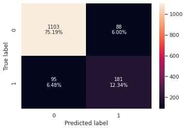

```python
confusion_matrix_sklearn(dtree, X_test, y_test)
```

**Check model performance on Training dataset**

```python
dtree_model_train_perf=model_performance_classification_sklearn(dtree, X_train, y_train)
print("Training performance \n",dtree_model_train_perf)
```

```
Training performance
    Accuracy  Recall  Precision   F1
0       1.0     1.0        1.0  1.0
```

As tree was created with pretty much default parameters, it grew in full size and tried to fit all the records so have the best score possible. It's overfit. Let's see how it behaves on Test.

**Check model performance on Test dataset**

```python
dtree_model_test_perf=model_performance_classification_sklearn(dtree, X_test, y_test)
print("Testing performance \n",dtree_model_test_perf)
```

```
Testing performance
    Accuracy    Recall  Precision       F1
0  0.875256  0.655797   0.672862  0.66422
```

Along with other metrics, the recall is much lower and have big gap with training data. The model is overfitted.

## **6.2 Model using Bagging Classifier**

Let's create with model with BaggingClassifier using default values

```python
bagging = BaggingClassifier(random_state=1)
bagging.fit(X_train,y_train)
```

```
BaggingClassifier(random_state=1)
```

**Create confusion matrix on Test data**

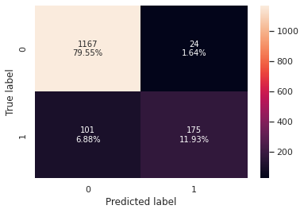

```python
confusion_matrix_sklearn(bagging, X_test, y_test)
```

**Check model performance on Train dataset**

```python
bagging_model_train_perf=model_performance_classification_sklearn(bagging, X_train, y_train)
print("Training performance \n",bagging_model_train_perf)
```

```
Training performance
    Accuracy    Recall  Precision        F1
0  0.995031  0.975155    0.99841  0.986646
```

All the metrics along with recall is much higher.

**Check model performance on Test dataset**

```python
bagging_model_test_perf=model_performance_classification_sklearn(bagging, X_test, y_test)
print("Testing performance \n",bagging_model_test_perf)
```

```
Testing performance
    Accuracy    Recall  Precision        F1
0  0.914792  0.634058   0.879397  0.736842
```

Again, the training score is much higher than testing score. Precision and F1 have improved but the one interests us the most - Recall - is still much lower. The model is overfitted.

Previously, we tried DecisionTree with class_weights, let's try BaggingClassfier with class_weights as well by taking Decision Tree as Base estimator.

```python
bagging_wt = BaggingClassifier(base_estimator=DecisionTreeClassifier(criterion='gini',class_weight={0:0.19,1:0.81},random_state=1),random_state=1)
bagging_wt.fit(X_train,y_train)
```

```
BaggingClassifier(base_estimator=DecisionTreeClassifier(class_weight={0: 0.19,
                                                                      1: 0.81},
                                                        random_state=1),
                  random_state=1)
```

**Create confusion matrix on Test data**

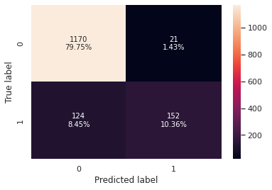

```python
confusion_matrix_sklearn(bagging_wt,X_test,y_test)
```

**Check model performance on Train dataset**

```python
bagging_wt_model_train_perf=model_performance_classification_sklearn(bagging_wt,X_train,y_train)
print("Training performance \n",bagging_wt_model_train_perf)
```

```
Training performance
    Accuracy    Recall  Precision       F1
0  0.993569  0.967391   0.998397  0.98265
```

Again, on training model performed well.

**Check model performance on Test dataset**

```python
bagging_wt_model_test_perf=model_performance_classification_sklearn(bagging_wt, X_test, y_test)
print("Testing performance \n",bagging_wt_model_test_perf)
```

```
Testing performance
    Accuracy    Recall  Precision       F1
0  0.901159  0.550725   0.878613  0.67706
```

Class weight brought the Recall score down further, which is not good.

## **6.3 Model using Random Forest Classifier**

Let's create Random Forest using default values

```python
rf = RandomForestClassifier(random_state=1)
rf.fit(X_train,y_train)
```

```
RandomForestClassifier(random_state=1)
```

**Create confusion matrix on Test data**

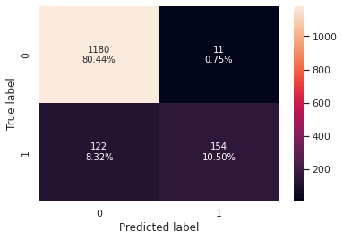

```python
confusion_matrix_sklearn(rf,X_test,y_test)
```

**Check model performance on Train dataset**

```python
rf_model_train_perf=model_performance_classification_sklearn(rf,X_train,y_train)
print("Training performance \n",rf_model_train_perf)
```

```
Training performance
    Accuracy  Recall  Precision   F1
0       1.0     1.0        1.0  1.0
```

As expected with default parameters, random forest gave the perfect score on training data.

**Check model performance on Test dataset**

```python
rf_model_test_perf=model_performance_classification_sklearn(rf,X_test,y_test)
print("Testing performance \n",rf_model_test_perf)
```

```
Testing performance
    Accuracy    Recall  Precision        F1
0  0.909339  0.557971   0.933333  0.698413
```

The recall score is still very low. Precision has improved a lot but we need Recall to get better. Again the model is overfitted.

Like DecisionTree and BaggingClassifier, let's try RandomForest with class weights too to see if there is any performance improvement.

```python
rf_wt = RandomForestClassifier(class_weight={0:0.17,1:0.83}, random_state=1)
rf_wt.fit(X_train,y_train)
```

```
RandomForestClassifier(class_weight={0: 0.17, 1: 0.83}, random_state=1)
```

**Create confusion matrix on Test data**

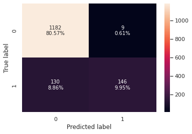

```python
confusion_matrix_sklearn(rf_wt, X_test,y_test)
```

**Check model performance on Train dataset**

```python
rf_wt_model_train_perf=model_performance_classification_sklearn(rf_wt, X_train,y_train)
print("Training performance \n",rf_wt_model_train_perf)
```

```
Training performance
    Accuracy  Recall  Precision   F1
0       1.0     1.0        1.0  1.0
```

**Check model performance on Test dataset**

```python
rf_wt_model_test_perf=model_performance_classification_sklearn(rf_wt, X_test,y_test)
print("Testing performance \n",rf_wt_model_test_perf)
```

```
Testing performance
    Accuracy    Recall  Precision        F1
0  0.905249  0.528986   0.941935  0.677494
```

Same like bagging classifier, after adding class weights, the recall score reduced further, which is not helpful.

Let's try above models with hyperparameter tuning.

# **7. Model Performance Improvement - Bagging Methods**

In previous section, we tried 3 different methods. Decision Tree, Random Forest and Bagging. None of these methods gave the good Recall score that we are looking for.

Let's tune all these methods and see how the recall score improves. We will do GridSearch to find out the best hyperparameter combination and apply that.

## **7.1 Model Performance Improvement - Decision Tree**

```python
# Choose the type of classifier.
dtree_estimator = DecisionTreeClassifier(class_weight={0:0.19,1:0.81},random_state=1)

# Grid of parameters to choose from
parameters = {'criterion':['gini', 'entropy'],
              'max_depth': np.arange(5,30),
              'min_samples_leaf': [1, 2, 5, 7, 10],
              'max_leaf_nodes' : [2, 3, 5, 10,15, None],
              'min_impurity_decrease': [0.0001,0.001,0.01,0.1]
             }

# Type of scoring used to compare parameter combinations
scorer = metrics.make_scorer(metrics.recall_score)

# Run the grid search
grid_obj = GridSearchCV(dtree_estimator, parameters, scoring=scorer)
grid_obj = grid_obj.fit(X_train, y_train)

# Set the clf to the best combination of parameters
dtree_estimator = grid_obj.best_estimator_

# Fit the best algorithm to the data.
dtree_estimator.fit(X_train, y_train)
```

```
DecisionTreeClassifier(class_weight={0: 0.19, 1: 0.81}, max_depth=15,
                       min_impurity_decrease=0.001, random_state=1)
```

Best parameters include max_depth of 15 and min_impurity_decrease of 0.001

**Create confusion matrix on Test data**

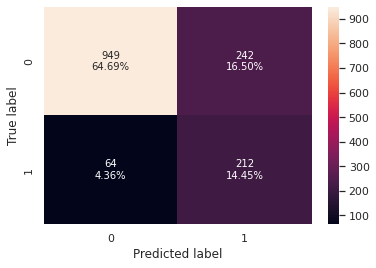

```python
confusion_matrix_sklearn(dtree_estimator, X_test,y_test)
```

**Check model performance on Train dataset**

```python
dtree_estimator_model_train_perf=model_performance_classification_sklearn(dtree_estimator, X_train,y_train)
print("Training performance \n",dtree_estimator_model_train_perf)
```

```
Training performance
    Accuracy    Recall  Precision        F1
0  0.862321  0.944099   0.582934  0.720806
```

Recall looks good on training.

**Check model performance on Test dataset**

```python
dtree_estimator_model_test_perf=model_performance_classification_sklearn(dtree_estimator, X_test, y_test)
print("Testing performance \n",dtree_estimator_model_test_perf)
```

```
Testing performance
    Accuracy    Recall  Precision        F1
0  0.791411  0.768116    0.46696  0.580822
```

Performance of recall score improved after hyperparameter tuning, still its not that good.

## **7.2 Model Performance Improvement - Bagging Classifier**

```python
# Choose the type of classifier.
bagging_estimator_tuned = BaggingClassifier(random_state=1)

# Grid of parameters to choose from
## add from article
#cl1 = DecisionTreeClassifier(random_state=1)
#cl2 = LogisticRegression(solver='liblinear',random_state=1,max_iter=1000)
parameters = {
    #'base_estimator':[cl1,cl2],
              'max_samples': [0.7,0.8,0.9,1],
              'max_features': [0.7,0.8,0.9,1],
              'n_estimators' : [10,20,30,40,50],
             }

# Type of scoring used to compare parameter combinations
acc_scorer = metrics.make_scorer(metrics.recall_score)

# Run the grid search
grid_obj = GridSearchCV(bagging_estimator_tuned, parameters, scoring=acc_scorer,cv=5)
grid_obj = grid_obj.fit(X_train, y_train)

# Set the clf to the best combination of parameters
bagging_estimator_tuned = grid_obj.best_estimator_

# Fit the best algorithm to the data.
bagging_estimator_tuned.fit(X_train, y_train)
```

```
BaggingClassifier(max_features=0.8, max_samples=0.9, n_estimators=50,
                  random_state=1)
```

Best parameters includes 80% of max_features, 90% of max_samples and 50 number of estimators.

**Create confusion matrix on Test data**

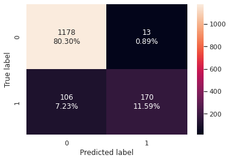

```python
confusion_matrix_sklearn(bagging_estimator_tuned, X_test,y_test)
```

**Check model performance on Train dataset**

```python
bagging_estimator_model_train_perf=model_performance_classification_sklearn(bagging_estimator_tuned, X_train,y_train)
print("Training performance \n",bagging_estimator_model_train_perf)
```

```
Training performance
    Accuracy    Recall  Precision        F1
0  0.999708  0.998447        1.0  0.999223
```

All scores look good on training data.

**Check model performance on Test dataset**

```python
bagging_estimator_model_test_perf=model_performance_classification_sklearn(bagging_estimator_tuned, X_test, y_test)
print("Testing performance \n",bagging_estimator_model_test_perf)
```

```
Testing performance
    Accuracy    Recall  Precision        F1
0  0.918882  0.615942   0.928962  0.740741
```

Recall is not good on testing data, Precision looks good.

Let's try with Logistics Regression once as well, just to see if it improves the scores.

```python
bagging_lr=BaggingClassifier(base_estimator=LogisticRegression(solver='liblinear',random_state=1,max_iter=1000),random_state=1)
bagging_lr.fit(X_train,y_train)
```

```
BaggingClassifier(base_estimator=LogisticRegression(max_iter=1000,
                                                    random_state=1,
                                                    solver='liblinear'),
                  random_state=1)
```

**Create confusion matrix on Test data**

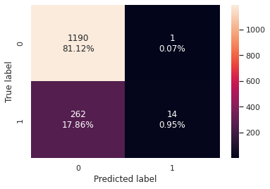

```python
confusion_matrix_sklearn(bagging_lr, X_test,y_test)
```

**Check model performance on Train dataset**

```python
bagging_lr_model_train_perf=model_performance_classification_sklearn(bagging_lr, X_train,y_train)
print("Training performance \n",bagging_lr_model_train_perf)
```

```
Training performance
    Accuracy    Recall  Precision        F1
0  0.823151  0.062112    0.97561  0.116788
```

Recall is very low on training.

**Check model performance on Test dataset**

```python
bagging_lr_model_test_perf=model_performance_classification_sklearn(bagging_lr, X_test,y_test)
print("Testing performance \n",bagging_lr_model_test_perf)
```

```
Testing performance
    Accuracy    Recall  Precision       F1
0  0.820723  0.050725   0.933333  0.09622
```

The recall score is very low, its not a good idea to use this.

## **7.3 Model Performance Improvement - Random Forest Classifier**

```python
# Choose the type of classifier.
rf_estimator = RandomForestClassifier(class_weight={0:0.19,1:0.81},random_state=1)

# Grid of parameters to choose from
parameters = {
        "n_estimators": [150,200,250],
        "min_samples_leaf": np.arange(1,6,1),
        "max_features": np.arange(0.2, 0.7, 0.1),
        "max_samples": np.arange(0.3, 0.7, 0.1),
}

# Run the grid search
grid_obj = GridSearchCV(rf_estimator, parameters, scoring='recall',cv=5)
grid_obj = grid_obj.fit(X_train, y_train)

# Set the clf to the best combination of parameters
rf_estimator = grid_obj.best_estimator_

# Fit the best algorithm to the data.
rf_estimator.fit(X_train, y_train)
```

```
RandomForestClassifier(class_weight={0: 0.19, 1: 0.81},
                       max_features=0.5000000000000001,
                       max_samples=0.6000000000000001, min_samples_leaf=5,
                       n_estimators=200, random_state=1)
```

**Create confusion matrix on Test data**

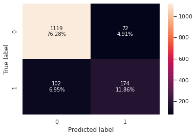

```python
confusion_matrix_sklearn(rf_estimator, X_test,y_test)
```

**Check model performance on Train dataset**

```python
rf_estimator_model_train_perf=model_performance_classification_sklearn(rf_estimator, X_train,y_train)
print("Training performance \n",rf_estimator_model_train_perf)
```

```
Training performance
    Accuracy    Recall  Precision       F1
0  0.944753  0.903727   0.820874  0.86031
```

All scores look good on training

**Check model performance on Test dataset**

```python
rf_estimator_model_test_perf=model_performance_classification_sklearn(rf_estimator, X_test,y_test)
print("Testing performance \n",rf_estimator_model_test_perf)
```

```
Testing performance
    Accuracy    Recall  Precision        F1
0  0.881391  0.630435   0.707317  0.666667
```

After hyperparameter tuning, recall has improved a bit compare to default values but still not that good.

## **7.4 Comparing all Bagging models**

Comparing all of above models on training data

```python
# training performance comparison

models_train_comp_df = pd.concat(
    [dtree_model_train_perf.T,
rf_model_train_perf.T,
rf_wt_model_train_perf.T,
bagging_model_train_perf.T,
bagging_wt_model_train_perf.T,
dtree_estimator_model_train_perf.T,
bagging_estimator_model_train_perf.T,
bagging_lr_model_train_perf.T,
rf_estimator_model_train_perf.T
],
axis=1,
)
models_train_comp_df.columns = [
    "Decision Tree",
    "Random Forest Classifier",
    "Weighted Random Forest Classifier",
    "Bagging Classifier",
    "Weighted Bagging Classifier",
    "Decision Tree Estimator",
    "Bagging Estimator",
    "Bagging Logistics Estimator",
    "Random Forest Estimator"]
print("Training performance comparison:")
models_train_comp_df
```

```
Training performance comparison:
```

|  | Decision Tree | Random Forest Classifier | Weighted Random Forest Classifier | Bagging Classifier | Weighted Bagging Classifier | Decision Tree Estimator | Bagging Estimator | Bagging Logistics Estimator | Random Forest Estimator |
| --- | --- | --- | --- | --- | --- | --- | --- | --- | --- |
| Accuracy | 1.0 | 1.0 | 1.0 | 0.995031 | 0.993569 | 0.862321 | 0.999708 | 0.823151 | 0.944753 |
| Recall | 1.0 | 1.0 | 1.0 | 0.975155 | 0.967391 | 0.944099 | 0.998447 | 0.062112 | 0.903727 |
| Precision | 1.0 | 1.0 | 1.0 | 0.998410 | 0.998397 | 0.582934 | 1.000000 | 0.975610 | 0.820874 |
| F1 | 1.0 | 1.0 | 1.0 | 0.986646 | 0.982650 | 0.720806 | 0.999223 | 0.116788 | 0.860310 |

Recall is pretty much good on all models except logistics.

Comparing all of above models on testing data

```python
# testing performance comparison

models_test_comp_df = pd.concat(
    [dtree_model_test_perf.T,
rf_model_test_perf.T,
rf_wt_model_test_perf.T,
bagging_model_test_perf.T,
bagging_wt_model_test_perf.T,
dtree_estimator_model_test_perf.T,
bagging_estimator_model_test_perf.T,
bagging_lr_model_test_perf.T,
rf_estimator_model_test_perf.T],
    axis=1,
)
models_test_comp_df.columns = [
    "Decision Tree",
    "Random Forest Classifier",
    "Weighted Random Forest Classifier",
    "Bagging Classifier",
    "Weighted Bagging Classifier",
    "Decision Tree Estimator",
    "Bagging Estimator",
    "Bagging Logistics Estimator",
    "Random Forest Estimator"]
print("Testing performance comparison:")
models_test_comp_df
```

```
Testing performance comparison:
```

|  | Decision Tree | Random Forest Classifier | Weighted Random Forest Classifier | Bagging Classifier | Weighted Bagging Classifier | Decision Tree Estimator | Bagging Estimator | Bagging Logistics Estimator | Random Forest Estimator |
| --- | --- | --- | --- | --- | --- | --- | --- | --- | --- |
| Accuracy | 0.875256 | 0.909339 | 0.905249 | 0.914792 | 0.901159 | 0.791411 | 0.918882 | 0.820723 | 0.881391 |
| Recall | 0.655797 | 0.557971 | 0.528986 | 0.634058 | 0.550725 | 0.768116 | 0.615942 | 0.050725 | 0.630435 |
| Precision | 0.672862 | 0.933333 | 0.941935 | 0.879397 | 0.878613 | 0.466960 | 0.928962 | 0.933333 | 0.707317 |
| F1 | 0.664220 | 0.698413 | 0.677494 | 0.736842 | 0.677060 | 0.580822 | 0.740741 | 0.096220 | 0.666667 |

The best recall was found on tuned Decision Tree classifier.

Let's find the important features for this model.

```python
feature_names = X_train.columns
importances = dtree_estimator.feature_importances_
indices = np.argsort(importances)
print (pd.DataFrame(dtree_estimator.feature_importances_, columns = ["Imp"], index = X_train.columns).sort_values(by = 'Imp', ascending = False))
```

```
                                    Imp
Age                            0.158956
DurationOfPitch                0.130086
Passport                       0.128127
PreferredPropertyStar          0.067497
ProductPitched_Basic           0.067149
CityTier                       0.057090
NumberOfTrips                  0.053462
NumberOfFollowups              0.043547
PitchSatisfactionScore         0.042873
MonthlyIncome                  0.036105
MaritalStatus_Single           0.031471
MaritalStatus_Married          0.022595
Occupation_Large Business      0.022089
ProductPitched_Deluxe          0.015021
NumberOfChildrenVisiting       0.014517
MaritalStatus_Unmarried        0.010782
Gender_Female                  0.010083
Occupation_Small Business      0.009991
ProductPitched_Standard        0.009400
Occupation_Salaried            0.008908
OwnCar                         0.008162
Gender_Male                    0.007278
Designation_VP                 0.007272
TypeofContact_Self Enquiry     0.006773
MaritalStatus_Divorced         0.006535
Designation_AVP                0.006264
NumberOfPersonVisiting         0.005400
ProductPitched_Super Deluxe    0.004848
Designation_Senior Manager     0.004414
Designation_Executive          0.003304
Occupation_Free Lancer         0.000000
TypeofContact_Unknown          0.000000
ProductPitched_King            0.000000
TypeofContact_Company Invited  0.000000
Designation_Manager            0.000000
```

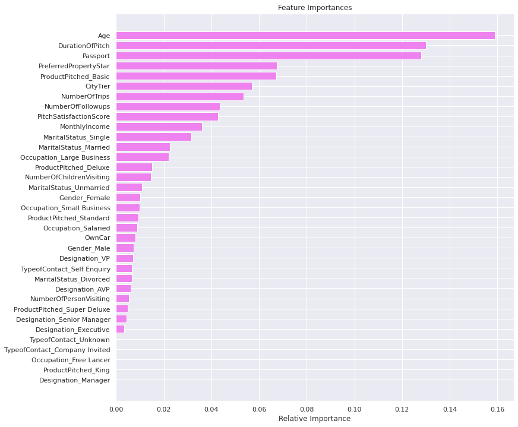

```python
importances = dtree_estimator.feature_importances_
indices = np.argsort(importances)

plt.figure(figsize=(12,12))
plt.title('Feature Importances')
plt.barh(range(len(indices)), importances[indices], color='violet', align='center')
plt.yticks(range(len(indices)), [feature_names[i] for i in indices])
plt.xlabel('Relative Importance')
plt.show()
```

Top features include age, duration of pitch, and passport.

# **8. Model building - Boosting Methods**

In this section we will try 4 boosing methods. Adaboost, Gradient, XGBoost and Stacking.

For analysis, we can use the same functions created earlier.

## **8.1 Model using Adaboost Classifier**

Let's start with default parameters

```python
abc = AdaBoostClassifier(random_state=1)
abc.fit(X_train,y_train)
```

```
AdaBoostClassifier(random_state=1)
```

**Create confusion matrix on Test data**

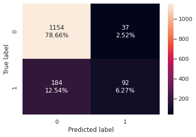

```python
confusion_matrix_sklearn(abc, X_test, y_test)
```

**Check model performance on Training dataset**

```python
abc_model_train_perf=model_performance_classification_sklearn(abc, X_train, y_train)
print("Training performance \n",abc_model_train_perf)
```

```
Training performance
    Accuracy    Recall  Precision        F1
0  0.845367  0.315217   0.697595  0.434225
```

The performance on recall is very poor on training itself.

**Check model performance on Test dataset**

```python
abc_model_test_perf=model_performance_classification_sklearn(abc, X_test, y_test)
print("Testing performance \n",abc_model_test_perf)
```

```
Testing performance
    Accuracy    Recall  Precision        F1
0  0.849352  0.333333   0.713178  0.454321
```

As expected its still poor on test. However, training and test performances are closer to each other compare to what we saw in bagging.

## **8.2 Model using Gradient Classifier**

```python
gbc = GradientBoostingClassifier(random_state=1)
gbc.fit(X_train,y_train)
```

```
GradientBoostingClassifier(random_state=1)
```

**Create confusion matrix on Test data**

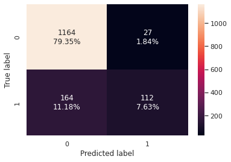

```python
confusion_matrix_sklearn(gbc, X_test, y_test)
```

**Check model performance on Training dataset**

```python
gbc_model_train_perf=model_performance_classification_sklearn(gbc, X_train, y_train)
print("Training performance \n",gbc_model_train_perf)
```

```
Training performance
    Accuracy    Recall  Precision        F1
0  0.887167  0.453416   0.895706  0.602062
```

Recall score is low in training itself.

**Check model performance on Testing dataset**

```python
gbc_model_test_perf=model_performance_classification_sklearn(gbc, X_test, y_test)
print("Testing performance \n",gbc_model_test_perf)
```

```
Testing performance
    Accuracy    Recall  Precision        F1
0  0.869802  0.405797   0.805755  0.539759
```

Recall score is low in testing as expected. Again, all scores are closer to training. Not overfitting.

## **8.3 Model using XGBoost Classifier**

```python
xgb = XGBClassifier(random_state=1,eval_metric='logloss')
xgb.fit(X_train,y_train)
```

```
XGBClassifier(eval_metric='logloss', random_state=1)
```

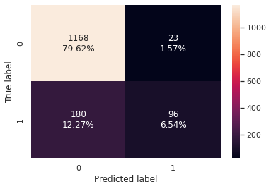

```python
confusion_matrix_sklearn(xgb, X_test, y_test)
```

```python
xgb_model_train_perf=model_performance_classification_sklearn(xgb, X_train, y_train)
print("Training performance \n",xgb_model_train_perf)
```

```
Training performance
    Accuracy    Recall  Precision        F1
0  0.878398  0.416149    0.87013  0.563025
```

Same like other boosing classifiers, recall is low in training itself.

```python
xgb_model_test_perf=model_performance_classification_sklearn(xgb, X_test, y_test)
print("Testing performance \n",xgb_model_test_perf)
```

```
Testing performance
    Accuracy    Recall  Precision        F1
0  0.861622  0.347826   0.806723  0.486076
```

Recall is further lower in testing.

## **8.4 Model using Stacking Classifier**

Let's try stacking with previously created models with default parameters and see the performance.

```python
estimators = [('Random Forest',rf_wt), ('Gradient Boosting',gbc), ('Decision Tree',dtree)]

final_estimator = xgb

stacking_classifier= StackingClassifier(estimators=estimators,final_estimator=final_estimator)

stacking_classifier.fit(X_train,y_train)
```

```
StackingClassifier(estimators=[('Random Forest',
                                RandomForestClassifier(class_weight={0: 0.17,
                                                                     1: 0.83},
                                                       random_state=1)),
                               ('Gradient Boosting',
                                GradientBoostingClassifier(random_state=1)),
                               ('Decision Tree',
                                DecisionTreeClassifier(class_weight={0: 0.19,
                                                                     1: 0.81},
                                                       random_state=1))],
                   final_estimator=XGBClassifier(eval_metric='logloss',
                                                 random_state=1))
```

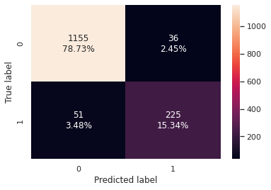

```python
confusion_matrix_sklearn(stacking_classifier, X_test, y_test)
```

```python
stacking_classifier_model_train_perf=model_performance_classification_sklearn(stacking_classifier, X_train, y_train)
print("Training performance \n",stacking_classifier_model_train_perf)
```

```
Training performance
    Accuracy  Recall  Precision   F1
0       1.0     1.0        1.0  1.0
```

On training it has a perfect score in all metrics.

```python
stacking_classifier_model_test_perf=model_performance_classification_sklearn(stacking_classifier, X_test, y_test)
print("Testing performance \n",stacking_classifier_model_test_perf)
```

```
Testing performance
    Accuracy    Recall  Precision        F1
0  0.940695  0.815217   0.862069  0.837989
```

Recall has improved a lot compare to all other models we have seen so far.

Let's try hyperparameter tuning in all of the above models and see if we can improve recall even further.

# **9. Model Performance Improvement - Boosting Methods**

In previous section, we tried 4 different methods. Adaboost, Gradient, XGBoost and Stacking.

Let's tune all these methods and see how the recall score improves. We will do GridSearch to find out the best hyperparameter combination and apply that.

## **9.1 Model Performance Improvement - Adaboost Classifier**

```python
# Choose the type of classifier.
abc_tuned = AdaBoostClassifier(random_state=1)

# Grid of parameters to choose from
parameters = {
    #Let's try different max_depth for base_estimator
    "base_estimator":[DecisionTreeClassifier(max_depth=1),DecisionTreeClassifier(max_depth=2),
                      DecisionTreeClassifier(max_depth=3)],
    "n_estimators": np.arange(10,110,10),
    "learning_rate":np.arange(0.1,2,0.1)
}

# Type of scoring used to compare parameter  combinations
scorer = metrics.make_scorer(metrics.recall_score)

# Run the grid search
grid_obj = GridSearchCV(abc_tuned, parameters, scoring=scorer,cv=5)
grid_obj = grid_obj.fit(X_train, y_train)

# Set the clf to the best combination of parameters
abc_tuned = grid_obj.best_estimator_

# Fit the best algorithm to the data.
abc_tuned.fit(X_train, y_train)
```

```
AdaBoostClassifier(base_estimator=DecisionTreeClassifier(max_depth=3),
                   learning_rate=1.1, n_estimators=90, random_state=1)
```

**Create confusion matrix on Test data**

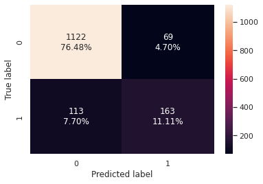

```python
confusion_matrix_sklearn(abc_tuned, X_test, y_test)
```

**Check model performance on Training dataset**

```python
abc_tuned_model_train_perf=model_performance_classification_sklearn(abc_tuned, X_train, y_train)
print("Training performance \n",abc_tuned_model_train_perf)
```

```
Training performance
    Accuracy    Recall  Precision        F1
0  0.983923  0.928571   0.985173  0.956035
```

Scores look on training data compare to default model.

**Check model performance on Test dataset**

```python
abc_tuned_model_test_perf=model_performance_classification_sklearn(abc_tuned, X_test, y_test)
print("Testing performance \n",abc_tuned_model_test_perf)
```

```
Testing performance
    Accuracy   Recall  Precision        F1
0  0.875937  0.59058   0.702586  0.641732
```

Recall has improved a bit than default but still on lower side.

## **9.2 Model Performance Improvement - Gradient Classifier**

```python
# Choose the type of classifier.
gbc_tuned = GradientBoostingClassifier(init=AdaBoostClassifier(random_state=1),random_state=1)

# Grid of parameters to choose from
parameters = {
    "n_estimators": [100,150,200,250],
    "subsample":[0.8,0.9,1],
    "max_features":[0.7,0.8,0.9,1]
}

# Type of scoring used to compare parameter combinations
scorer = metrics.make_scorer(metrics.recall_score)

# Run the grid search
grid_obj = GridSearchCV(gbc_tuned, parameters, scoring=scorer,cv=5)
grid_obj = grid_obj.fit(X_train, y_train)

# Set the clf to the best combination of parameters
gbc_tuned = grid_obj.best_estimator_

# Fit the best algorithm to the data.
gbc_tuned.fit(X_train, y_train)
```

```
GradientBoostingClassifier(init=AdaBoostClassifier(random_state=1),
                           max_features=0.7, n_estimators=250, random_state=1,
                           subsample=0.8)
```

**Create confusion matrix on Test data**

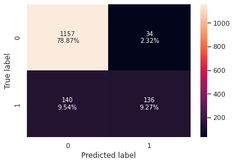

```python
confusion_matrix_sklearn(gbc_tuned, X_test, y_test)
```

**Check model performance on Training dataset**

```python
gbc_tuned_model_train_perf=model_performance_classification_sklearn(gbc_tuned, X_train, y_train)
print("Training performance \n",gbc_tuned_model_train_perf)
```

```
Training performance
    Accuracy    Recall  Precision        F1
0  0.918445  0.607143    0.93765  0.737041
```

Recall is not that good on training data.

**Check model performance on Test dataset**

```python
gbc_tuned_model_test_perf=model_performance_classification_sklearn(gbc_tuned, X_test, y_test)
print("Testing performance \n",gbc_tuned_model_test_perf)
```

```
Testing performance
    Accuracy    Recall  Precision        F1
0  0.881391  0.492754        0.8  0.609865
```

Recall is not good on testing data as well. It improved compare to default model but still not that good.

## **9.3 Model Performance Improvement - XGBoost Classifier**

```python
# Choose the type of classifier.
xgb_tuned = XGBClassifier(random_state=1, eval_metric='logloss')

# Grid of parameters to choose from
parameters = {
    "n_estimators": [10,30,50],
    "scale_pos_weight":[1,2,5],
    "subsample":[0.7,0.9,1],
    "learning_rate":[0.05, 0.1,0.2],
    "colsample_bytree":[0.7,0.9,1],
    "colsample_bylevel":[0.5,0.7,1]
}

# Type of scoring used to compare parameter combinations
scorer = metrics.make_scorer(metrics.recall_score)

# Run the grid search
grid_obj = GridSearchCV(xgb_tuned, parameters,scoring=scorer,cv=5)
grid_obj = grid_obj.fit(X_train, y_train)

# Set the clf to the best combination of parameters
xgb_tuned = grid_obj.best_estimator_

# Fit the best algorithm to the data.
xgb_tuned.fit(X_train, y_train)
```

```
XGBClassifier(colsample_bylevel=0.7, colsample_bytree=0.7,
              eval_metric='logloss', learning_rate=0.2, n_estimators=50,
              random_state=1, scale_pos_weight=5, subsample=0.7)
```

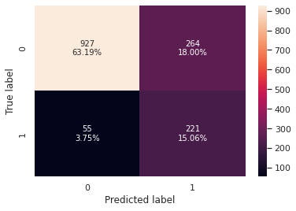

```python
confusion_matrix_sklearn(xgb_tuned, X_test, y_test)
```

**Check model performance on Training dataset**

```python
xgb_tuned_model_train_perf=model_performance_classification_sklearn(xgb_tuned, X_train, y_train)
print("Training performance \n",xgb_tuned_model_train_perf)
```

```
Training performance
    Accuracy    Recall  Precision        F1
0  0.811166  0.833851   0.499071  0.624419
```

Recall score looks good on training data.

**Check model performance on Test dataset**

```python
xgb_tuned_model_test_perf=model_performance_classification_sklearn(xgb_tuned, X_test, y_test)
print("Testing performance \n",xgb_tuned_model_test_perf)
```

```
Testing performance
    Accuracy    Recall  Precision        F1
0  0.782549  0.800725    0.45567  0.580815
```

Recall score has improved after hyperparameter tuning. Let's see if we can make it even better with stacking next.

## **9.4 Model Performance Improvement - Stacking Classifier**

Let's try stacking classifier using tuned models.

```python
estimators = [('Random Forest',rf_estimator), ('Gradient Boosting',gbc_tuned), ('Decision Tree',dtree_estimator)]

final_estimator = xgb_tuned

stacking_classifier_tuned= StackingClassifier(estimators=estimators,final_estimator=final_estimator)

stacking_classifier_tuned.fit(X_train,y_train)
```

```
StackingClassifier(estimators=[('Random Forest',
                                RandomForestClassifier(class_weight={0: 0.19,
                                                                     1: 0.81},
                                                       max_features=0.5000000000000001,
                                                       max_samples=0.6000000000000001,
                                                       min_samples_leaf=5,
                                                       n_estimators=200,
                                                       random_state=1)),
                               ('Gradient Boosting',
                                GradientBoostingClassifier(init=AdaBoostClassifier(random_state=1),
                                                           max_features=0.7,
                                                           n_estimators=250,
                                                           random_state=1,
                                                           subsample=0.8)),
                               ('Decision Tree',
                                DecisionTreeClassifier(class_weight={0: 0.19,
                                                                     1: 0.81},
                                                       max_depth=15,
                                                       min_impurity_decrease=0.001,
                                                       random_state=1))],
                   final_estimator=XGBClassifier(colsample_bylevel=0.7,
                                                 colsample_bytree=0.7,
                                                 eval_metric='logloss',
                                                 learning_rate=0.2,
                                                 n_estimators=50,
                                                 random_state=1,
                                                 scale_pos_weight=5,
                                                 subsample=0.7))
```

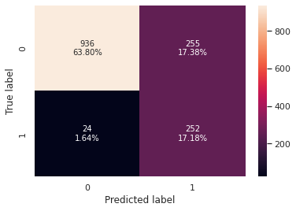

```python
confusion_matrix_sklearn(stacking_classifier_tuned, X_test, y_test)
```

**Check model performance on Training dataset**

```python
stacking_classifier_tuned_model_train_perf=model_performance_classification_sklearn(stacking_classifier_tuned, X_train, y_train)
print("Training performance \n",stacking_classifier_tuned_model_train_perf)
```

```
Training performance
    Accuracy    Recall  Precision        F1
0  0.876352  0.995342   0.604147  0.751906
```

Recall looks good on training data.

**Check model performance on Test dataset**

```python
stacking_classifier_tuned_model_test_perf=model_performance_classification_sklearn(stacking_classifier_tuned, X_test, y_test)
print("Testing performance \n",stacking_classifier_tuned_model_test_perf)
```

```
Testing performance
    Accuracy    Recall  Precision        F1
0  0.809816  0.913043   0.497041  0.643678
```

Recall looks good testing data also. It is the best we have seen so far.

## **9.5 Comparing all Boosting models**

Comparing all the models on training data

```python
# training performance comparison

models_train_comp_df = pd.concat(
    [abc_model_train_perf.T,
gbc_model_train_perf.T,
xgb_model_train_perf.T,
stacking_classifier_model_train_perf.T,
abc_tuned_model_train_perf.T,
gbc_tuned_model_train_perf.T,
xgb_tuned_model_train_perf.T,
stacking_classifier_tuned_model_train_perf.T
],
axis=1,
)
models_train_comp_df.columns = [
    "Adaboost Classifier",
    "Gradient Classifier",
    "XGBoost Classifier",
    "Stacking Classifier",
    "Adaboost Tuned Classifier",
    "Gradient Tuned Classifier",
    "XGBoost Tuned Classifier",
    "Stacking Tuned Classifier"
    ]
print("Training performance comparison:")
models_train_comp_df
```

```
Training performance comparison:
```

|  | Adaboost Classifier | Gradient Classifier | XGBoost Classifier | Stacking Classifier | Adaboost Tuned Classifier | Gradient Tuned Classifier | XGBoost Tuned Classifier | Stacking Tuned Classifier |
| --- | --- | --- | --- | --- | --- | --- | --- | --- |
| Accuracy | 0.845367 | 0.887167 | 0.878398 | 1.0 | 0.983923 | 0.918445 | 0.811166 | 0.876352 |
| Recall | 0.315217 | 0.453416 | 0.416149 | 1.0 | 0.928571 | 0.607143 | 0.833851 | 0.995342 |
| Precision | 0.697595 | 0.895706 | 0.870130 | 1.0 | 0.985173 | 0.937650 | 0.499071 | 0.604147 |
| F1 | 0.434225 | 0.602062 | 0.563025 | 1.0 | 0.956035 | 0.737041 | 0.624419 | 0.751906 |

Comparing all the models on testing data

```python
# testing performance comparison

models_test_comp_df = pd.concat(
    [abc_model_test_perf.T,
gbc_model_test_perf.T,
xgb_model_test_perf.T,
stacking_classifier_model_test_perf.T,
abc_tuned_model_test_perf.T,
gbc_tuned_model_test_perf.T,
xgb_tuned_model_test_perf.T,
stacking_classifier_tuned_model_test_perf.T],
    axis=1,
)
models_test_comp_df.columns = [
    "Adaboost Classifier",
    "Gradient Classifier",
    "XGBoost Classifier",
    "Stacking Classifier",
    "Adaboost Tuned Classifier",
    "Gradient Tuned Classifier",
    "XGBoost Tuned Classifier",
    "Stacking Tuned Classifier"
    ]
print("Testing performance comparison:")
models_test_comp_df
```

```
Testing performance comparison:
```

|  | Adaboost Classifier | Gradient Classifier | XGBoost Classifier | Stacking Classifier | Adaboost Tuned Classifier | Gradient Tuned Classifier | XGBoost Tuned Classifier | Stacking Tuned Classifier |
| --- | --- | --- | --- | --- | --- | --- | --- | --- |
| Accuracy | 0.849352 | 0.869802 | 0.861622 | 0.940695 | 0.875937 | 0.881391 | 0.782549 | 0.809816 |
| Recall | 0.333333 | 0.405797 | 0.347826 | 0.815217 | 0.590580 | 0.492754 | 0.800725 | 0.913043 |
| Precision | 0.713178 | 0.805755 | 0.806723 | 0.862069 | 0.702586 | 0.800000 | 0.455670 | 0.497041 |
| F1 | 0.454321 | 0.539759 | 0.486076 | 0.837989 | 0.641732 | 0.609865 | 0.580815 | 0.643678 |

Recall was best on stacking tuned classfier where we used tuned decision tree, tuned random forest, tuned gradient classifier as estimators and took tuned XG boost as final estimator. It doesn't give great precision or f1 scores compare to other models but its not that bad also.

I would consider to use tuned stacking classifier for this use case as that gave the best results.

Let's find the important features for this model. As we can't use important features on stacking, let's try on gbc_tuned and xgb_tuned models.

```python
feature_names = X_train.columns
importances = xgb_tuned.feature_importances_
indices = np.argsort(importances)
print (pd.DataFrame(xgb_tuned.feature_importances_, columns = ["Imp"], index = X_train.columns).sort_values(by = 'Imp', ascending = False))
```

```
                                    Imp
ProductPitched_Basic           0.116061
Passport                       0.079031
MaritalStatus_Married          0.054082
Designation_Senior Manager     0.050513
MaritalStatus_Single           0.043072
ProductPitched_Super Deluxe    0.039152
CityTier                       0.039101
Designation_AVP                0.031501
PreferredPropertyStar          0.031452
Occupation_Large Business      0.031073
TypeofContact_Self Enquiry     0.030128
TypeofContact_Company Invited  0.029550
PitchSatisfactionScore         0.028834
MaritalStatus_Unmarried        0.027550
Age                            0.025535
MaritalStatus_Divorced         0.025066
Occupation_Salaried            0.024674
NumberOfTrips                  0.024640
MonthlyIncome                  0.024574
Designation_Executive          0.024306
NumberOfFollowups              0.023318
DurationOfPitch                0.022058
Occupation_Small Business      0.020994
NumberOfChildrenVisiting       0.019895
ProductPitched_Standard        0.018334
ProductPitched_King            0.018286
Designation_VP                 0.017746
ProductPitched_Deluxe          0.016073
Gender_Female                  0.015102
OwnCar                         0.014387
NumberOfPersonVisiting         0.013719
Gender_Male                    0.013346
Designation_Manager            0.006846
TypeofContact_Unknown          0.000000
Occupation_Free Lancer         0.000000
```

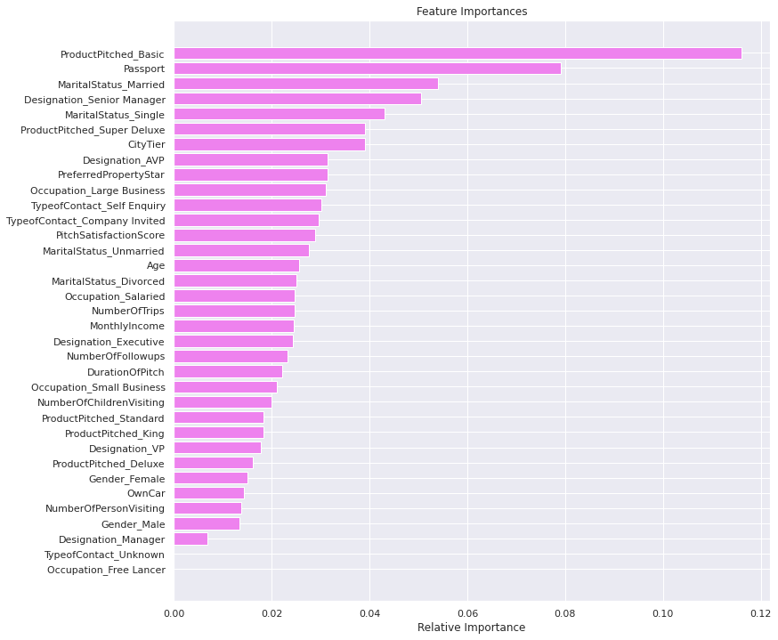

```python
importances = xgb_tuned.feature_importances_
indices = np.argsort(importances)

plt.figure(figsize=(12,12))
plt.title('Feature Importances')
plt.barh(range(len(indices)), importances[indices], color='violet', align='center')
plt.yticks(range(len(indices)), [feature_names[i] for i in indices])
plt.xlabel('Relative Importance')
plt.show()
```

The most important feature is product pitched basic followed by Passport and married marital status.

```python
feature_names = X_train.columns
importances = gbc_tuned.feature_importances_
indices = np.argsort(importances)
print (pd.DataFrame(gbc_tuned.feature_importances_, columns = ["Imp"], index = X_train.columns).sort_values(by = 'Imp', ascending = False))
```

```
                                    Imp
MonthlyIncome                  0.176535
Age                            0.132524
Passport                       0.113222
DurationOfPitch                0.078116
CityTier                       0.063725
Designation_Executive          0.056099
NumberOfFollowups              0.052944
MaritalStatus_Single           0.049722
NumberOfTrips                  0.036845
PitchSatisfactionScore         0.035029
ProductPitched_Basic           0.034294
PreferredPropertyStar          0.033305
MaritalStatus_Unmarried        0.027796
Occupation_Large Business      0.011474
ProductPitched_Standard        0.010748
Designation_Senior Manager     0.008954
TypeofContact_Company Invited  0.008457
Gender_Female                  0.007726
NumberOfChildrenVisiting       0.007565
NumberOfPersonVisiting         0.007409
TypeofContact_Self Enquiry     0.007098
Gender_Male                    0.006478
MaritalStatus_Married          0.005473
MaritalStatus_Divorced         0.004728
ProductPitched_Deluxe          0.004482
OwnCar                         0.004013
Occupation_Salaried            0.002944
Designation_AVP                0.002803
ProductPitched_Super Deluxe    0.002595
Occupation_Small Business      0.002572
Designation_Manager            0.001566
Designation_VP                 0.001336
TypeofContact_Unknown          0.001266
ProductPitched_King            0.000106
Occupation_Free Lancer         0.000048
```

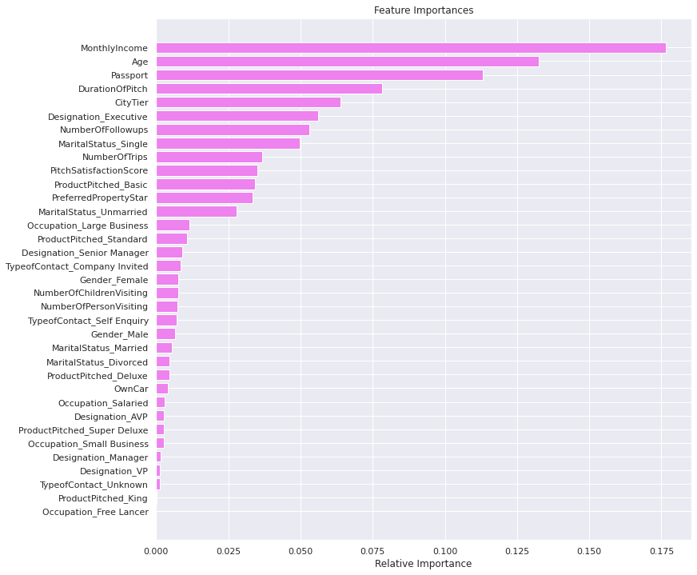

```python
importances = gbc_tuned.feature_importances_
indices = np.argsort(importances)

plt.figure(figsize=(12,12))
plt.title('Feature Importances')
plt.barh(range(len(indices)), importances[indices], color='violet', align='center')
plt.yticks(range(len(indices)), [feature_names[i] for i in indices])
plt.xlabel('Relative Importance')
plt.show()
```

Monthly income and Age are the most import features followed by Passport.

```python
feature_names = X_train.columns
importances = rf_estimator.feature_importances_
indices = np.argsort(importances)
print (pd.DataFrame(rf_estimator.feature_importances_, columns = ["Imp"], index = X_train.columns).sort_values(by = 'Imp', ascending = False))
```

```
                                    Imp
Passport                       0.112320
MonthlyIncome                  0.112041
Age                            0.106812
DurationOfPitch                0.099576
CityTier                       0.058563
PitchSatisfactionScore         0.049959
NumberOfTrips                  0.047982
PreferredPropertyStar          0.042038
NumberOfFollowups              0.041153
Designation_Executive          0.036694
ProductPitched_Basic           0.036077
MaritalStatus_Single           0.031437
MaritalStatus_Married          0.023440
NumberOfChildrenVisiting       0.017323
MaritalStatus_Unmarried        0.015500
OwnCar                         0.014741
MaritalStatus_Divorced         0.014433
NumberOfPersonVisiting         0.014167
Occupation_Salaried            0.013691
Gender_Female                  0.013524
TypeofContact_Company Invited  0.013201
Gender_Male                    0.012501
Occupation_Small Business      0.012425
TypeofContact_Self Enquiry     0.011298
Occupation_Large Business      0.010475
Designation_Manager            0.007805
ProductPitched_Standard        0.007430
ProductPitched_Deluxe          0.006742
Designation_Senior Manager     0.005673
ProductPitched_Super Deluxe    0.004963
Designation_AVP                0.004261
Designation_VP                 0.000992
ProductPitched_King            0.000734
TypeofContact_Unknown          0.000030
Occupation_Free Lancer         0.000000
```

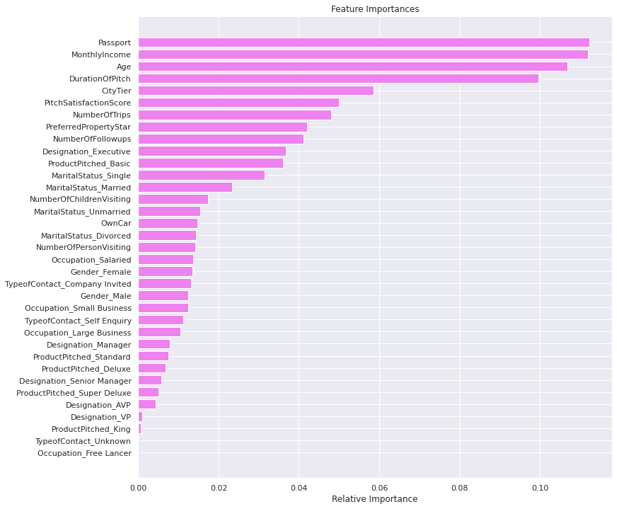

```python
importances = rf_estimator.feature_importances_
indices = np.argsort(importances)

plt.figure(figsize=(12,12))
plt.title('Feature Importances')
plt.barh(range(len(indices)), importances[indices], color='violet', align='center')
plt.yticks(range(len(indices)), [feature_names[i] for i in indices])
plt.xlabel('Relative Importance')
plt.show()
```

Passport, Monthly Income, Age and Duration of Pitch are the most important features. Column passport was found important feature with all the models we have seen so far.

# **10. Summary of Insights & Recommendations**

As part of this project, we have analyzed the customer data of "Visit with us", a tourism company, to find a way to increase their customer base via offering them the new tour package.

Based on the nature of the objective and the data provided, recall metrics was the best to measure for both the kind of modeling.

To achieve the goal, we tried multiple bagging and boosing modeling techniques. We started with 3 different bagging models (decision tree, random forest and bagging classifier). First we tried with default parameters and then tried with hyperparameter tuning. Out of all these models, we got best results when decision tree was tried with hyperparameters. The recall score was ~ 0.76

Next we tried 4 boosting models. Adaboost, Gradient, XGboost and stack. Again, first we tried as-is with default parameters and then with hyperparameter tuning. The best results we got when we tried stack with tuned estimators like gradient, xgboost, decision tree and randomforest. The recall score was ~0.91. We concluded that was the best model to work with for this dataset.

While working on all these models and doing EDA, I have gatherd below insights and recommendations.

- Having a passport turned out to be a very important feature in many models. Comapny should encourage their customers to get passport, their likelyhood of buying a package increases. Company can even keep passport application form in the office, provide passport agent contacts to their customers, any such thing that can make customer get passport easily.
- The number of follow ups has a direct impact in customer buying a tour package. More follow ups result in more sold tour packages. So sales person should not give up on potential clients and do regular follow ups.
- Cusotmers with higher monthly income tend to buy more tour packages. Also, higher income customers buy Super Deluxe and King packages. By name, it looks like they are expensive ones. Company should try to target higher income customers more so they can sell such high end packages to make more profits.
- Same like monthly income, customers with older age tend to buy Super Deluxe and King packages. So company should target old customers to get more profit as they would buy such premium packages. Also, the new package that company wants to start revolve around healthier lifestyle, so it would encourage older people more compare to rest.
- Sales people have 5 different kind pitches for 5 packages. Most of the pitches were either for Basic or Deluxe. Maximum turn around observed in Basic pitch. However, in spite of spending so many pitches (second highest) on Deluxe, the turn around is very low percentage wise. Sales people need to focus more on basic and at the same time either improve upon Deluxe or try save time by cutting down and focus on other packages like Standard.
- Higher pitch satisfaction score helps to get more customers buy tour packages. Most of the score is around 3, sales people should get trained more so they can improve their score to 4 or 5.
- It was seen that customers travelling solo or with 5 people do not prefer to take tour packages. Mostly people travelling 2,3 or 4 buy packages. Also, maximum customers who bought packages are single or unmarried. So company should try to lure married people or people with 1 or 2 children to increase their customer base. They can introduce family friendly packages, like resorts with children parks, on-site day care etc.
- Customers living lower tiers like 2 or 3 prefer more tour packages. Company should advertise more in such tire cities.
- Customer who prefer 5 start properties tend to buy more tour packages. Company should add more such hotels into their packages and also try to focus on such customers who prefers that.
- Customer's designation also have important role. During modeling, it was in top features as well. Executives and Senior managers buy more tour packages. Marketing team should invite such people in 'company invited' events. We saw when it was contacted by company, chances of customer taking tour package slightly increases as well.
- Customer who are Free lancer or have large business tend to buy more tour packages. However, the data is too little for these 2 occupations. Company should try to find more such customers and see if the sales of tour packages increases.